# Import des librairies

```python
import numpy as np
import pandas as pd
import seaborn as sns
import matplotlib
import matplotlib.pyplot as plt
import pylab
import re
import time
from datetime import date
import plotly

from imblearn.over_sampling import BorderlineSMOTE
from imblearn.under_sampling import RandomUnderSampler
from xgboost import XGBClassifier
from lightgbm import LGBMClassifier
from sklearn.dummy import DummyClassifier
from sklearn.neighbors import KNeighborsClassifier
from sklearn.tree import DecisionTreeClassifier
from sklearn.ensemble import RandomForestClassifier
from sklearn.ensemble import AdaBoostClassifier
from sklearn.ensemble import GradientBoostingClassifier
from sklearn.naive_bayes import GaussianNB
from sklearn.linear_model import LogisticRegression
from sklearn.model_selection import RepeatedStratifiedKFold,cross_val_score,train_test_split,GridSearchCV
from sklearn.metrics import classification_report,confusion_matrix
from sklearn.metrics import f1_score,fbeta_score,accuracy_score,roc_auc_score
from sklearn.metrics import precision_score,recall_score,make_scorer,plot_confusion_matrix
from sklearn.metrics import average_precision_score,precision_recall_curve
from sklearn.impute import SimpleImputer
from sklearn.preprocessing import MinMaxScaler
from sklearn.metrics import auc, roc_curve, roc_auc_score
from lightgbm import LGBMClassifier
from imblearn.over_sampling import SMOTE, SMOTENC
from sklearn.model_selection import KFold, StratifiedKFold
from hyperopt import hp, fmin, tpe, STATUS_OK, Trials, space_eval
import itertools
```

```python
pd.set_option('display.max_row', 1001)
pd.set_option('display.max_column', 400)
# pd.set_option('display.column_space', 200)
# pd.set_option('display.width', 10000)

import warnings
warnings.simplefilter(action='ignore', category=FutureWarning)
```

# Functions

```python
def nan_df_create(data):

    '''
    Function to create a dataframe of percentage of NaN values for each column of the dataframe

    Inputs:
        data:
            DataFrame

    Returns:
        DataFrame of NaN percentages
    '''

    nan_percentages = data.isna().sum() * 100 / len(data)
    df = pd.DataFrame({'column' : nan_percentages.index, 'percent' : nan_percentages.values})

    #sorting the dataframe by decreasing order of percentage of NaN values
    df.sort_values(by = 'percent', ascending = False, inplace = True)

    return df


def plot_nan_percent(df_nan, title_name, tight_layout = True, figsize = (20,8), grid = False, rotation = 90):

    '''
    Function to plot Bar Plots of NaN percentages for each Column with missing values

    Inputs:
        df_nan:
            DataFrame of NaN percentages
        title_name:
            Name of table to be displayed in title of plot
        tight_layout: bool, default = True
            Whether to keep tight layout or not
        figsize: tuple, default = (20,8)
            Figure size of plot
        grid: bool, default = False
            Whether to draw gridlines to plot or not
        rotation: int, default = 0
            Degree of rotation for x-tick labels
    '''

    #checking if there is any column with NaNs or not.
    if df_nan.percent.sum() != 0:
        print(f"Number of columns having NaN values: {df_nan[df_nan['percent'] != 0].shape[0]} columns")

        #plotting the Bar-Plot for NaN percentages (only for columns with Non-Zero percentage of NaN values)
        plt.figure(figsize = figsize, tight_layout = tight_layout)
        sns.barplot(x= 'column', y = 'percent', data = df_nan[df_nan['percent'] > 0])
        plt.xticks(rotation = rotation)
        plt.xlabel('Column Name')
        plt.ylabel('Percentage of NaN values')
        plt.title(f'Percentage of NaN values in {title_name}')
        if grid:
            plt.grid()
        plt.show()
    else:
        print(f"The dataframe {title_name} does not contain any NaN values.")


def plot_stats(df, feature,title,label_rotation=False,horizontal_layout=True):
    labels = ['Remboursé', 'Non Remboursé']
    sns.countplot(x=feature, hue='TARGET', data=df, palette='Blues')
    plt.legend(labels = labels, frameon=True)
    plt.xticks(rotation = 90)
    plt.title(title)
    plt.show()

def remove_missing_columns(df, threshold):

    # Calculate missing stats for df
    df_miss = pd.DataFrame(df.isnull().sum())
    df_miss['percent'] = 100 * df_miss[0] / len(df)

    # list of missing columns for df
    missing_df_columns = list(df_miss.index[df_miss['percent'] > threshold])

    # Print information
    print('There are %d columns with greater than %d%% missing values.' % (len(missing_df_columns), threshold))

    # Drop the missing columns and return
    df = df.drop(columns = missing_df_columns)

    return df

def plot_confusion_matrix1(cm, classes,
                          normalize='all',
                          title='Confusion matrix',
                          cmap=plt.cm.Blues):

    cm = cm.astype('float') / cm.sum(axis=1)[:, np.newaxis]
    plt.imshow(cm, interpolation='nearest', cmap=cmap)
    plt.title(title)
    plt.colorbar()
    tick_marks = np.arange(len(classes))
    plt.xticks(tick_marks, classes, rotation=45)
    plt.yticks(tick_marks, classes)
    fmt = '.2f'
    thresh = cm.max() / 2.
    for i, j in itertools.product(range(cm.shape[0]),   range(cm.shape[1])):
        plt.text(j, i, format(cm[i, j], fmt),
                 horizontalalignment="center",
                 color="white" if cm[i, j] > thresh else "black")

    plt.tight_layout()
    plt.ylabel('True label')
    plt.xlabel('Predicted label')
```

https://www.kaggle.com/jsaguiar/lightgbm-with-simple-features/

https://www.kaggle.com/code/atilaysamiloglu/home-credit-default-dsmlbc4-gr2

```python
# Most features are created by applying min, max, mean, sum and var functions to grouped tables.
# Little feature selection is done and overfitting might be a problem since many features are related.
# The following key ideas were used:
# - Divide or subtract important features to get rates (like annuity and income)
# - In Bureau Data: create specific features for Active credits and Closed credits
# - In Previous Applications: create specific features for Approved and Refused applications
# - Modularity: one function for each table (except bureau_balance and application_test)
# - One-hot encoding for categorical features
# All tables are joined with the application DF using the SK_ID_CURR key (except bureau_balance).

# One-hot encoding for categorical columns with get_dummies
def one_hot_encoder(df, nan_as_category = True):
    original_columns = list(df.columns)
    categorical_columns = [col for col in df.columns if df[col].dtype == 'object']
    df = pd.get_dummies(df, columns= categorical_columns, dummy_na= nan_as_category)
    new_columns = [c for c in df.columns if c not in original_columns]
    return df, new_columns

# Preprocess application_train.csv and application_test.csv
def application_train_test(nan_as_category = False):
    # Read data and merge
    df = application_train
    test_df = application_test
    print("Train samples: {}, test samples: {}".format(len(df), len(test_df)))
    df = df.append(test_df).reset_index()

    # Categorical features with Binary encode (0 or 1; two categories)
    for bin_feature in ['CODE_GENDER', 'FLAG_OWN_CAR', 'FLAG_OWN_REALTY']:
        df[bin_feature], uniques = pd.factorize(df[bin_feature])
    # Categorical features with One-Hot encode
    df, cat_cols = one_hot_encoder(df, nan_as_category)

    # NaN values for DAYS_EMPLOYED: 365.243 -> nan
    df['DAYS_EMPLOYED'].replace(365243, np.nan, inplace= True)
    # Some simple new features (percentages)
    df['DAYS_EMPLOYED_PERC'] = df['DAYS_EMPLOYED'] / df['DAYS_BIRTH']
    df['INCOME_CREDIT_PERC'] = df['AMT_INCOME_TOTAL'] / df['AMT_CREDIT']
    df['INCOME_PER_PERSON'] = df['AMT_INCOME_TOTAL'] / df['CNT_FAM_MEMBERS']
    df['ANNUITY_INCOME_PERC'] = df['AMT_ANNUITY'] / df['AMT_INCOME_TOTAL']
    df['PAYMENT_RATE'] = df['AMT_ANNUITY'] / df['AMT_CREDIT']

    return df

# Preprocess bureau.csv and bureau_balance.csv
def bureau_and_balance(nan_as_category = True):
    bureau_df = bureau
    bb = bureau_balance

    bb, bb_cat = one_hot_encoder(bb, nan_as_category)
    bureau_df, bureau_cat = one_hot_encoder(bureau_df, nan_as_category)

    # Bureau balance: Perform aggregations and merge with bureau.csv
    bb_aggregations = {'MONTHS_BALANCE': ['min', 'max', 'size']}
    for col in bb_cat:
        bb_aggregations[col] = ['mean']
    bb_agg = bb.groupby('SK_ID_BUREAU').agg(bb_aggregations)
    bb_agg.columns = pd.Index([e[0] + "_" + e[1].upper() for e in bb_agg.columns.tolist()])
    bureau_df = bureau_df.join(bb_agg, how='left', on='SK_ID_BUREAU')
    bureau_df.drop(['SK_ID_BUREAU'], axis=1, inplace= True)

    # Bureau and bureau_balance numeric features
    num_aggregations = {
        'DAYS_CREDIT': ['min', 'max', 'mean', 'var'],
        'DAYS_CREDIT_ENDDATE': ['min', 'max', 'mean'],
        'DAYS_CREDIT_UPDATE': ['mean'],
        'CREDIT_DAY_OVERDUE': ['max', 'mean'],
        'AMT_CREDIT_MAX_OVERDUE': ['mean'],
        'AMT_CREDIT_SUM': ['max', 'mean', 'sum'],
        'AMT_CREDIT_SUM_DEBT': ['max', 'mean', 'sum'],
        'AMT_CREDIT_SUM_OVERDUE': ['mean'],
        'AMT_CREDIT_SUM_LIMIT': ['mean', 'sum'],
        'AMT_ANNUITY': ['max', 'mean'],
        'CNT_CREDIT_PROLONG': ['sum'],
        'MONTHS_BALANCE_MIN': ['min'],
        'MONTHS_BALANCE_MAX': ['max'],
        'MONTHS_BALANCE_SIZE': ['mean', 'sum']
    }

    # Bureau and bureau_balance categorical features
    cat_aggregations = {}
    for cat in bureau_cat: cat_aggregations[cat] = ['mean']
    for cat in bb_cat: cat_aggregations[cat + "_MEAN"] = ['mean']

    bureau_agg = bureau_df.groupby('SK_ID_CURR').agg({**num_aggregations, **cat_aggregations})
    bureau_agg.columns = pd.Index(['BURO_' + e[0] + "_" + e[1].upper() for e in bureau_agg.columns.tolist()])

    # Bureau: Active credits - using only numerical aggregations
    active = bureau_df[bureau_df['CREDIT_ACTIVE_Active'] == 1]
    active_agg = active.groupby('SK_ID_CURR').agg(num_aggregations)
    active_agg.columns = pd.Index(['ACTIVE_' + e[0] + "_" + e[1].upper() for e in active_agg.columns.tolist()])
    bureau_agg = bureau_agg.join(active_agg, how='left', on='SK_ID_CURR')

    # Bureau: Closed credits - using only numerical aggregations
    closed = bureau_df[bureau_df['CREDIT_ACTIVE_Closed'] == 1]
    closed_agg = closed.groupby('SK_ID_CURR').agg(num_aggregations)
    closed_agg.columns = pd.Index(['CLOSED_' + e[0] + "_" + e[1].upper() for e in closed_agg.columns.tolist()])
    bureau_agg = bureau_agg.join(closed_agg, how='left', on='SK_ID_CURR')

    return bureau_agg

# Preprocess previous_applications.csv
def previous_applications(nan_as_category = True):
    prev = previous_application
    prev, cat_cols = one_hot_encoder(prev, nan_as_category= True)
    # Days 365.243 values -> nan
    prev['DAYS_FIRST_DRAWING'].replace(365243, np.nan, inplace= True)
    prev['DAYS_FIRST_DUE'].replace(365243, np.nan, inplace= True)
    prev['DAYS_LAST_DUE_1ST_VERSION'].replace(365243, np.nan, inplace= True)
    prev['DAYS_LAST_DUE'].replace(365243, np.nan, inplace= True)
    prev['DAYS_TERMINATION'].replace(365243, np.nan, inplace= True)
    # Add feature: value ask / value received percentage
    prev['APP_CREDIT_PERC'] = prev['AMT_APPLICATION'] / prev['AMT_CREDIT']
    # Previous applications numeric features
    num_aggregations = {
        'AMT_ANNUITY': ['min', 'max', 'mean'],
        'AMT_APPLICATION': ['min', 'max', 'mean'],
        'AMT_CREDIT': ['min', 'max', 'mean'],
        'APP_CREDIT_PERC': ['min', 'max', 'mean', 'var'],
        'AMT_DOWN_PAYMENT': ['min', 'max', 'mean'],
        'AMT_GOODS_PRICE': ['min', 'max', 'mean'],
        'HOUR_APPR_PROCESS_START': ['min', 'max', 'mean'],
        'RATE_DOWN_PAYMENT': ['min', 'max', 'mean'],
        'DAYS_DECISION': ['min', 'max', 'mean'],
        'CNT_PAYMENT': ['mean', 'sum'],
    }
    # Previous applications categorical features
    cat_aggregations = {}
    for cat in cat_cols:
        cat_aggregations[cat] = ['mean']

    prev_agg = prev.groupby('SK_ID_CURR').agg({**num_aggregations, **cat_aggregations})
    prev_agg.columns = pd.Index(['PREV_' + e[0] + "_" + e[1].upper() for e in prev_agg.columns.tolist()])
    # Previous Applications: Approved Applications - only numerical features
    approved = prev[prev['NAME_CONTRACT_STATUS_Approved'] == 1]
    approved_agg = approved.groupby('SK_ID_CURR').agg(num_aggregations)
    approved_agg.columns = pd.Index(['APPROVED_' + e[0] + "_" + e[1].upper() for e in approved_agg.columns.tolist()])
    prev_agg = prev_agg.join(approved_agg, how='left', on='SK_ID_CURR')
    # Previous Applications: Refused Applications - only numerical features
    refused = prev[prev['NAME_CONTRACT_STATUS_Refused'] == 1]
    refused_agg = refused.groupby('SK_ID_CURR').agg(num_aggregations)
    refused_agg.columns = pd.Index(['REFUSED_' + e[0] + "_" + e[1].upper() for e in refused_agg.columns.tolist()])
    prev_agg = prev_agg.join(refused_agg, how='left', on='SK_ID_CURR')

    return prev_agg

# Preprocess POS_CASH_balance.csv
def pos_cash(nan_as_category = True):
    pos = POS_CASH_balance
    pos, cat_cols = one_hot_encoder(pos, nan_as_category= True)
    # Features
    aggregations = {
        'MONTHS_BALANCE': ['max', 'mean', 'size'],
        'SK_DPD': ['max', 'mean'],
        'SK_DPD_DEF': ['max', 'mean']
    }
    for cat in cat_cols:
        aggregations[cat] = ['mean']

    pos_agg = pos.groupby('SK_ID_CURR').agg(aggregations)
    pos_agg.columns = pd.Index(['POS_' + e[0] + "_" + e[1].upper() for e in pos_agg.columns.tolist()])
    # Count pos cash accounts
    pos_agg['POS_COUNT'] = pos.groupby('SK_ID_CURR').size()

    return pos_agg

# Preprocess installments_payments.csv
def installments(nan_as_category = True):
    ins = installments_payments
    ins, cat_cols = one_hot_encoder(ins, nan_as_category= True)
    # Percentage and difference paid in each installment (amount paid and installment value)
    ins['PAYMENT_PERC'] = ins['AMT_PAYMENT'] / ins['AMT_INSTALMENT']
    ins['PAYMENT_DIFF'] = ins['AMT_INSTALMENT'] - ins['AMT_PAYMENT']
    # Days past due and days before due (no negative values)
    ins['DPD'] = ins['DAYS_ENTRY_PAYMENT'] - ins['DAYS_INSTALMENT']
    ins['DBD'] = ins['DAYS_INSTALMENT'] - ins['DAYS_ENTRY_PAYMENT']
    ins['DPD'] = ins['DPD'].apply(lambda x: x if x > 0 else 0)
    ins['DBD'] = ins['DBD'].apply(lambda x: x if x > 0 else 0)
    # Features: Perform aggregations
    aggregations = {
        'NUM_INSTALMENT_VERSION': ['nunique'],
        'DPD': ['max', 'mean', 'sum'],
        'DBD': ['max', 'mean', 'sum'],
        'PAYMENT_PERC': ['max', 'mean', 'sum', 'var'],
        'PAYMENT_DIFF': ['max', 'mean', 'sum', 'var'],
        'AMT_INSTALMENT': ['max', 'mean', 'sum'],
        'AMT_PAYMENT': ['min', 'max', 'mean', 'sum'],
        'DAYS_ENTRY_PAYMENT': ['max', 'mean', 'sum']
    }
    for cat in cat_cols:
        aggregations[cat] = ['mean']
    ins_agg = ins.groupby('SK_ID_CURR').agg(aggregations)
    ins_agg.columns = pd.Index(['INSTAL_' + e[0] + "_" + e[1].upper() for e in ins_agg.columns.tolist()])
    # Count installments accounts
    ins_agg['INSTAL_COUNT'] = ins.groupby('SK_ID_CURR').size()

    return ins_agg

# Preprocess credit_card_balance.csv
def credit_card(nan_as_category = True):
    cc = credit_card_balance
    cc, cat_cols = one_hot_encoder(cc, nan_as_category= True)
    # General aggregations
    cc.drop(['SK_ID_PREV'], axis= 1, inplace = True)
    cc_agg = cc.groupby('SK_ID_CURR').agg(['min', 'max', 'mean', 'sum', 'var'])
    cc_agg.columns = pd.Index(['CC_' + e[0] + "_" + e[1].upper() for e in cc_agg.columns.tolist()])
    # Count credit card lines
    cc_agg['CC_COUNT'] = cc.groupby('SK_ID_CURR').size()

    return cc_agg
```

# Chargement des données

```python
application_train = pd.read_csv("application_train.csv")
application_test = pd.read_csv("application_test.csv")
bureau = pd.read_csv("bureau.csv")
bureau_balance = pd.read_csv("bureau_balance.csv")
previous_application = pd.read_csv("previous_application.csv")
POS_CASH_balance = pd.read_csv("POS_CASH_balance.csv")
installments_payments = pd.read_csv("installments_payments.csv")
credit_card_balance = pd.read_csv("credit_card_balance.csv")
sample_submission = pd.read_csv("sample_submission.csv")
homecredit = pd.read_csv('HomeCredit_columns_description.csv')
```

# Description des données

```python
datasets_dict = {"application_train": application_train, "application_test": application_test,
                 "bureau": bureau, "bureau_balance": bureau_balance,
                 "previous_application": previous_application,"POS_CASH_balance": POS_CASH_balance,
                 "installments_payments":installments_payments,"credit_card_balance": credit_card_balance,
                 "sample_submission": sample_submission, "home_credit":homecredit }
```

```python
for item in datasets_dict:
    print("**")
    print("Le jeu de données %s contient %d lignes et %d colonnes." % (item, datasets_dict[item].shape[0], datasets_dict[item].shape[1]))
    print(f"{datasets_dict[item].duplicated().sum()} doublons et {(datasets_dict[item].isna().sum().sum() / datasets_dict[item].shape[0]/datasets_dict[item].shape[1])*100} % Nans")
```

```
**
Le jeu de données application_train contient 307511 lignes et 122 colonnes.
0 doublons et 24.39594190712943 % Nans
**
Le jeu de données application_test contient 48744 lignes et 121 colonnes.
0 doublons et 23.81168676153234 % Nans
**
Le jeu de données bureau contient 1716428 lignes et 17 colonnes.
0 doublons et 13.502552290879322 % Nans
**
Le jeu de données bureau_balance contient 27299925 lignes et 3 colonnes.
0 doublons et 0.0 % Nans
**
Le jeu de données previous_application contient 1670214 lignes et 37 colonnes.
0 doublons et 17.97687747344498 % Nans
**
Le jeu de données POS_CASH_balance contient 10001358 lignes et 8 colonnes.
0 doublons et 0.06518864738168557 % Nans
**
Le jeu de données installments_payments contient 13605401 lignes et 8 colonnes.
0 doublons et 0.005337953655316738 % Nans
**
Le jeu de données credit_card_balance contient 3840312 lignes et 23 colonnes.
0 doublons et 6.654074392687479 % Nans
**
Le jeu de données sample_submission contient 48744 lignes et 2 colonnes.
0 doublons et 0.0 % Nans
**
Le jeu de données home_credit contient 219 lignes et 5 colonnes.
0 doublons et 12.146118721461189 % Nans
```

```python
for item in datasets_dict:
    print("###########################################################")
    print(item)
    print(datasets_dict[item].columns)
```

```
###########################################################
application_train
Index(['SK_ID_CURR', 'TARGET', 'NAME_CONTRACT_TYPE', 'CODE_GENDER',
       'FLAG_OWN_CAR', 'FLAG_OWN_REALTY', 'CNT_CHILDREN', 'AMT_INCOME_TOTAL',
       'AMT_CREDIT', 'AMT_ANNUITY',
       ...
       'FLAG_DOCUMENT_18', 'FLAG_DOCUMENT_19', 'FLAG_DOCUMENT_20',
       'FLAG_DOCUMENT_21', 'AMT_REQ_CREDIT_BUREAU_HOUR',
       'AMT_REQ_CREDIT_BUREAU_DAY', 'AMT_REQ_CREDIT_BUREAU_WEEK',
       'AMT_REQ_CREDIT_BUREAU_MON', 'AMT_REQ_CREDIT_BUREAU_QRT',
       'AMT_REQ_CREDIT_BUREAU_YEAR'],
      dtype='object', length=122)
###########################################################
application_test
Index(['SK_ID_CURR', 'NAME_CONTRACT_TYPE', 'CODE_GENDER', 'FLAG_OWN_CAR',
       'FLAG_OWN_REALTY', 'CNT_CHILDREN', 'AMT_INCOME_TOTAL', 'AMT_CREDIT',
       'AMT_ANNUITY', 'AMT_GOODS_PRICE',
       ...
       'FLAG_DOCUMENT_18', 'FLAG_DOCUMENT_19', 'FLAG_DOCUMENT_20',
       'FLAG_DOCUMENT_21', 'AMT_REQ_CREDIT_BUREAU_HOUR',
       'AMT_REQ_CREDIT_BUREAU_DAY', 'AMT_REQ_CREDIT_BUREAU_WEEK',
       'AMT_REQ_CREDIT_BUREAU_MON', 'AMT_REQ_CREDIT_BUREAU_QRT',
       'AMT_REQ_CREDIT_BUREAU_YEAR'],
      dtype='object', length=121)
###########################################################
bureau
Index(['SK_ID_CURR', 'SK_ID_BUREAU', 'CREDIT_ACTIVE', 'CREDIT_CURRENCY',
       'DAYS_CREDIT', 'CREDIT_DAY_OVERDUE', 'DAYS_CREDIT_ENDDATE',
       'DAYS_ENDDATE_FACT', 'AMT_CREDIT_MAX_OVERDUE', 'CNT_CREDIT_PROLONG',
       'AMT_CREDIT_SUM', 'AMT_CREDIT_SUM_DEBT', 'AMT_CREDIT_SUM_LIMIT',
       'AMT_CREDIT_SUM_OVERDUE', 'CREDIT_TYPE', 'DAYS_CREDIT_UPDATE',
       'AMT_ANNUITY'],
      dtype='object')
###########################################################
bureau_balance
Index(['SK_ID_BUREAU', 'MONTHS_BALANCE', 'STATUS'], dtype='object')
###########################################################
previous_application
Index(['SK_ID_PREV', 'SK_ID_CURR', 'NAME_CONTRACT_TYPE', 'AMT_ANNUITY',
       'AMT_APPLICATION', 'AMT_CREDIT', 'AMT_DOWN_PAYMENT', 'AMT_GOODS_PRICE',
```

[output cut: 28 more lines]

```
       'AMT_DRAWINGS_CURRENT', 'AMT_DRAWINGS_OTHER_CURRENT',
       'AMT_DRAWINGS_POS_CURRENT', 'AMT_INST_MIN_REGULARITY',
       'AMT_PAYMENT_CURRENT', 'AMT_PAYMENT_TOTAL_CURRENT',
       'AMT_RECEIVABLE_PRINCIPAL', 'AMT_RECIVABLE', 'AMT_TOTAL_RECEIVABLE',
       'CNT_DRAWINGS_ATM_CURRENT', 'CNT_DRAWINGS_CURRENT',
       'CNT_DRAWINGS_OTHER_CURRENT', 'CNT_DRAWINGS_POS_CURRENT',
       'CNT_INSTALMENT_MATURE_CUM', 'NAME_CONTRACT_STATUS', 'SK_DPD',
       'SK_DPD_DEF'],
      dtype='object')
###########################################################
sample_submission
Index(['SK_ID_CURR', 'TARGET'], dtype='object')
###########################################################
home_credit
Index(['Unnamed: 0', 'Table', 'Row', 'Description', 'Special'], dtype='object')
```

## Home Credit

```python
homecredit
```

|  | Unnamed: 0 | Table | Row | Description | Special |
| --- | --- | --- | --- | --- | --- |
| 0 | 1 | application_{train\|test}.csv | SK_ID_CURR | ID of loan in our sample | NaN |
| 1 | 2 | application_{train\|test}.csv | TARGET | Target variable (1 - client with payment diffi... | NaN |
| 2 | 5 | application_{train\|test}.csv | NAME_CONTRACT_TYPE | Identification if loan is cash or revolving | NaN |
| 3 | 6 | application_{train\|test}.csv | CODE_GENDER | Gender of the client | NaN |
| 4 | 7 | application_{train\|test}.csv | FLAG_OWN_CAR | Flag if the client owns a car | NaN |
| 5 | 8 | application_{train\|test}.csv | FLAG_OWN_REALTY | Flag if client owns a house or flat | NaN |
| 6 | 9 | application_{train\|test}.csv | CNT_CHILDREN | Number of children the client has | NaN |
| 7 | 10 | application_{train\|test}.csv | AMT_INCOME_TOTAL | Income of the client | NaN |
| 8 | 11 | application_{train\|test}.csv | AMT_CREDIT | Credit amount of the loan | NaN |
| 9 | 12 | application_{train\|test}.csv | AMT_ANNUITY | Loan annuity | NaN |
| 10 | 13 | application_{train\|test}.csv | AMT_GOODS_PRICE | For consumer loans it is the price of the good... | NaN |
| 11 | 14 | application_{train\|test}.csv | NAME_TYPE_SUITE | Who was accompanying client when he was applyi... | NaN |
| 12 | 15 | application_{train\|test}.csv | NAME_INCOME_TYPE | Clients income type (businessman, working, mat... | NaN |
| 13 | 16 | application_{train\|test}.csv | NAME_EDUCATION_TYPE | Level of highest education the client achieved | NaN |
| 14 | 17 | application_{train\|test}.csv | NAME_FAMILY_STATUS | Family status of the client | NaN |
| 15 | 18 | application_{train\|test}.csv | NAME_HOUSING_TYPE | What is the housing situation of the client (r... | NaN |
| 16 | 19 | application_{train\|test}.csv | REGION_POPULATION_RELATIVE | Normalized population of region where client l... | normalized |
| 17 | 20 | application_{train\|test}.csv | DAYS_BIRTH | Client's age in days at the time of application | time only relative to the application |
| 18 | 21 | application_{train\|test}.csv | DAYS_EMPLOYED | How many days before the application the perso... | time only relative to the application |
| 19 | 22 | application_{train\|test}.csv | DAYS_REGISTRATION | How many days before the application did clien... | time only relative to the application |
| 20 | 23 | application_{train\|test}.csv | DAYS_ID_PUBLISH | How many days before the application did clien... | time only relative to the application |
| 21 | 24 | application_{train\|test}.csv | OWN_CAR_AGE | Age of client's car | NaN |
| 22 | 25 | application_{train\|test}.csv | FLAG_MOBIL | Did client provide mobile phone (1=YES, 0=NO) | NaN |
| 23 | 26 | application_{train\|test}.csv | FLAG_EMP_PHONE | Did client provide work phone (1=YES, 0=NO) | NaN |
| 24 | 27 | application_{train\|test}.csv | FLAG_WORK_PHONE | Did client provide home phone (1=YES, 0=NO) | NaN |
| 25 | 28 | application_{train\|test}.csv | FLAG_CONT_MOBILE | Was mobile phone reachable (1=YES, 0=NO) | NaN |
| 26 | 29 | application_{train\|test}.csv | FLAG_PHONE | Did client provide home phone (1=YES, 0=NO) | NaN |
| 27 | 30 | application_{train\|test}.csv | FLAG_EMAIL | Did client provide email (1=YES, 0=NO) | NaN |
| 28 | 31 | application_{train\|test}.csv | OCCUPATION_TYPE | What kind of occupation does the client have | NaN |
| 29 | 32 | application_{train\|test}.csv | CNT_FAM_MEMBERS | How many family members does client have | NaN |

[output cut: 189 more lines]

```
Homecredit contient les descriptions des colonnes des différents fichiers de données.
```

## application_train et application_test

### application_train

Il s'agit de la table principale, avec TARGET. Données statiques pour toutes les applications. Une ligne représente un prêt dans notre échantillon de données.

```python
application_train.head()
```

|  | SK_ID_CURR | TARGET | NAME_CONTRACT_TYPE | CODE_GENDER | FLAG_OWN_CAR | FLAG_OWN_REALTY | CNT_CHILDREN | AMT_INCOME_TOTAL | AMT_CREDIT | AMT_ANNUITY | AMT_GOODS_PRICE | NAME_TYPE_SUITE | NAME_INCOME_TYPE | NAME_EDUCATION_TYPE | NAME_FAMILY_STATUS | NAME_HOUSING_TYPE | REGION_POPULATION_RELATIVE | DAYS_BIRTH | DAYS_EMPLOYED | DAYS_REGISTRATION | DAYS_ID_PUBLISH | OWN_CAR_AGE | FLAG_MOBIL | FLAG_EMP_PHONE | FLAG_WORK_PHONE | FLAG_CONT_MOBILE | FLAG_PHONE | FLAG_EMAIL | OCCUPATION_TYPE | … |
| --- | --- | --- | --- | --- | --- | --- | --- | --- | --- | --- | --- | --- | --- | --- | --- | --- | --- | --- | --- | --- | --- | --- | --- | --- | --- | --- | --- | --- | --- | --- |
| 0 | 100002 | 1 | Cash loans | M | N | Y | 0 | 202500.0 | 406597.5 | 24700.5 | 351000.0 | Unaccompanied | Working | Secondary / secondary special | Single / not married | House / apartment | 0.018801 | -9461 | -637 | -3648.0 | -2120 | NaN | 1 | 1 | 0 | 1 | 1 | 0 | Laborers | … |
| 1 | 100003 | 0 | Cash loans | F | N | N | 0 | 270000.0 | 1293502.5 | 35698.5 | 1129500.0 | Family | State servant | Higher education | Married | House / apartment | 0.003541 | -16765 | -1188 | -1186.0 | -291 | NaN | 1 | 1 | 0 | 1 | 1 | 0 | Core staff | … |
| 2 | 100004 | 0 | Revolving loans | M | Y | Y | 0 | 67500.0 | 135000.0 | 6750.0 | 135000.0 | Unaccompanied | Working | Secondary / secondary special | Single / not married | House / apartment | 0.010032 | -19046 | -225 | -4260.0 | -2531 | 26.0 | 1 | 1 | 1 | 1 | 1 | 0 | Laborers | … |
| 3 | 100006 | 0 | Cash loans | F | N | Y | 0 | 135000.0 | 312682.5 | 29686.5 | 297000.0 | Unaccompanied | Working | Secondary / secondary special | Civil marriage | House / apartment | 0.008019 | -19005 | -3039 | -9833.0 | -2437 | NaN | 1 | 1 | 0 | 1 | 0 | 0 | Laborers | … |
| 4 | 100007 | 0 | Cash loans | M | N | Y | 0 | 121500.0 | 513000.0 | 21865.5 | 513000.0 | Unaccompanied | Working | Secondary / secondary special | Single / not married | House / apartment | 0.028663 | -19932 | -3038 | -4311.0 | -3458 | NaN | 1 | 1 | 0 | 1 | 0 | 0 | Core staff | … |

```
Number of columns having NaN values: 67 columns
```

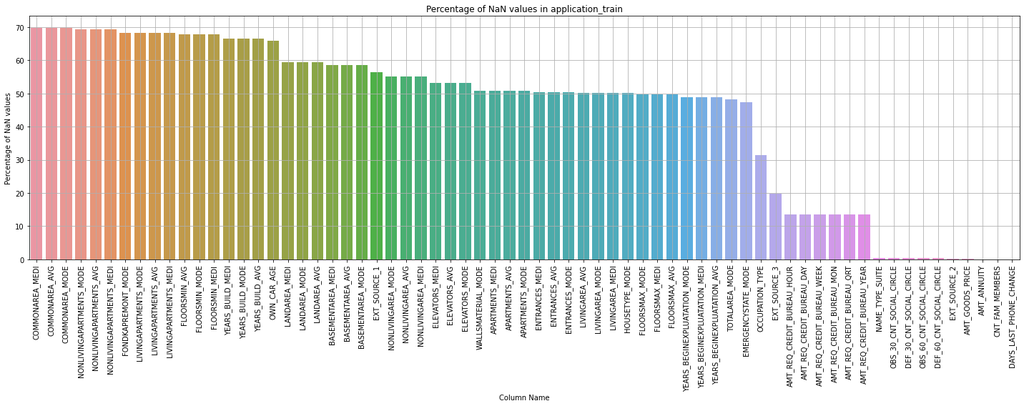

```python
#### NaN Columns and Percentages
plot_nan_percent(nan_df_create(application_train), 'application_train', grid = True)
```

### application_test

Il s'agit de la table principale sans TARGET

```python
application_test.head()
```

|  | SK_ID_CURR | NAME_CONTRACT_TYPE | CODE_GENDER | FLAG_OWN_CAR | FLAG_OWN_REALTY | CNT_CHILDREN | AMT_INCOME_TOTAL | AMT_CREDIT | AMT_ANNUITY | AMT_GOODS_PRICE | NAME_TYPE_SUITE | NAME_INCOME_TYPE | NAME_EDUCATION_TYPE | NAME_FAMILY_STATUS | NAME_HOUSING_TYPE | REGION_POPULATION_RELATIVE | DAYS_BIRTH | DAYS_EMPLOYED | DAYS_REGISTRATION | DAYS_ID_PUBLISH | OWN_CAR_AGE | FLAG_MOBIL | FLAG_EMP_PHONE | FLAG_WORK_PHONE | FLAG_CONT_MOBILE | FLAG_PHONE | FLAG_EMAIL | OCCUPATION_TYPE | CNT_FAM_MEMBERS | … |
| --- | --- | --- | --- | --- | --- | --- | --- | --- | --- | --- | --- | --- | --- | --- | --- | --- | --- | --- | --- | --- | --- | --- | --- | --- | --- | --- | --- | --- | --- | --- |
| 0 | 100001 | Cash loans | F | N | Y | 0 | 135000.0 | 568800.0 | 20560.5 | 450000.0 | Unaccompanied | Working | Higher education | Married | House / apartment | 0.018850 | -19241 | -2329 | -5170.0 | -812 | NaN | 1 | 1 | 0 | 1 | 0 | 1 | NaN | 2.0 | … |
| 1 | 100005 | Cash loans | M | N | Y | 0 | 99000.0 | 222768.0 | 17370.0 | 180000.0 | Unaccompanied | Working | Secondary / secondary special | Married | House / apartment | 0.035792 | -18064 | -4469 | -9118.0 | -1623 | NaN | 1 | 1 | 0 | 1 | 0 | 0 | Low-skill Laborers | 2.0 | … |
| 2 | 100013 | Cash loans | M | Y | Y | 0 | 202500.0 | 663264.0 | 69777.0 | 630000.0 | NaN | Working | Higher education | Married | House / apartment | 0.019101 | -20038 | -4458 | -2175.0 | -3503 | 5.0 | 1 | 1 | 0 | 1 | 0 | 0 | Drivers | 2.0 | … |
| 3 | 100028 | Cash loans | F | N | Y | 2 | 315000.0 | 1575000.0 | 49018.5 | 1575000.0 | Unaccompanied | Working | Secondary / secondary special | Married | House / apartment | 0.026392 | -13976 | -1866 | -2000.0 | -4208 | NaN | 1 | 1 | 0 | 1 | 1 | 0 | Sales staff | 4.0 | … |
| 4 | 100038 | Cash loans | M | Y | N | 1 | 180000.0 | 625500.0 | 32067.0 | 625500.0 | Unaccompanied | Working | Secondary / secondary special | Married | House / apartment | 0.010032 | -13040 | -2191 | -4000.0 | -4262 | 16.0 | 1 | 1 | 1 | 1 | 0 | 0 | NaN | 3.0 | … |

```
Number of columns having NaN values: 64 columns
```

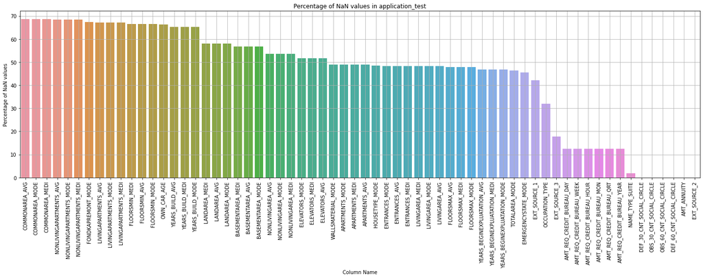

```python
#### NaN Columns and Percentages
plot_nan_percent(nan_df_create(application_test), 'application_test', grid = True)
```

Le pourcentages de valeurs NaNs sont assez similaires à ceux présents dans l'ensemble de données Train. On peut en conclure que les ensembles train et de test ont une distribution à peu près similaire.

### Analyse exploratoire

**Répartition de la variable cible "TARGET" selon les deux classes**

- 0 : le crédit est remboursé
- 1 : le crédit est non remboursé

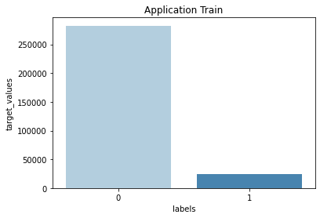

```python
target = application_train["TARGET"].value_counts()
df = pd.DataFrame({'labels': target.index,
                   'target_values': target.values
                  })
plt.title('Application Train')
sns.barplot(x = 'labels', y="target_values", data=df, palette='Blues')
plt.show()
```

On peut voir qu'il y a un déséquilibre des données. Le jeu de données contient largement plus de crédit remboursé que non remboursé.

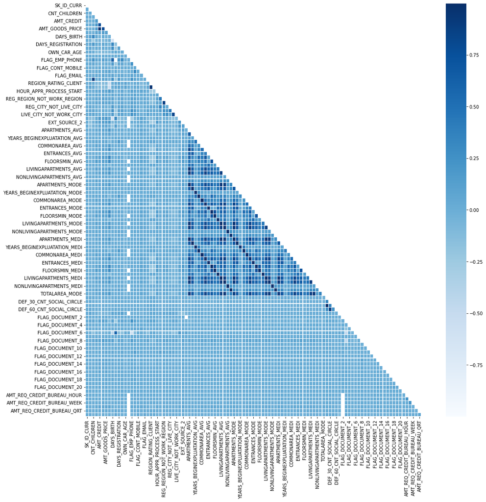

```python
# Corrélations des variables numériques : Matrice de corrélation heatmap
matrix=application_train.corr()
fig,axes=plt.subplots(figsize=(17,17))
mask_array = np.ones(matrix.shape)
mask_array = np.triu(mask_array)
sns.heatmap(matrix, annot = False, mask = mask_array, linewidth = 0.1, cmap = 'Blues')
```

**Distribution de NAME_CONTRACT_TYPE**

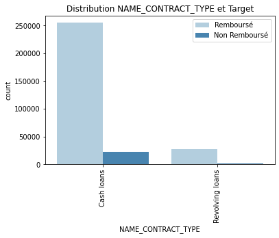

```python
plot_stats(application_train,'NAME_CONTRACT_TYPE',"Distribution NAME_CONTRACT_TYPE et Target")
```

La plupart des prêts que les clients contractent sont en cash.

**Distribution des clients par genre**

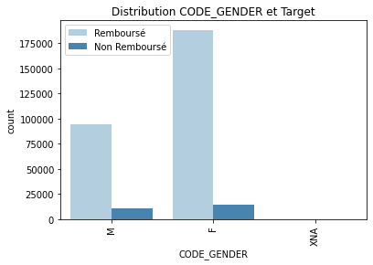

```python
plot_stats(application_train,'CODE_GENDER',"Distribution CODE_GENDER et Target")
```

```python
application_train.CODE_GENDER.value_counts()
```

```
F      202448
M      105059
XNA         4
Name: CODE_GENDER, dtype: int64
```

Il y a 4 lignes dans la table application_train qui ont des genres 'XNA' et peut donc être compté comme des valeurs NaN.

```
Il y a plus de clients féminins que de candidats masculins.
```

**Distribution des clients par éducation**

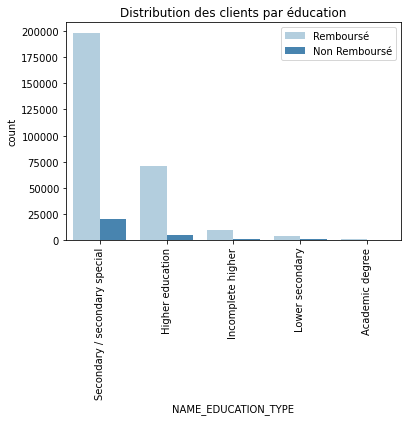

```python
plot_stats(application_train,'NAME_EDUCATION_TYPE', 'Distribution des clients par éducation')
```

**Distribution des clients par âge**

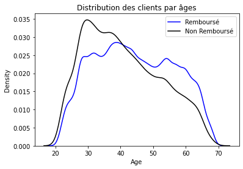

```python
sns.kdeplot(application_train[application_train['TARGET'] == 0]['DAYS_BIRTH'] / -365, label = 'Remboursé', color='b')
sns.kdeplot(application_train[application_train['TARGET'] == 1]['DAYS_BIRTH'] / -365, label = 'Non Remboursé', color='black')
plt.legend()

plt.xlabel('Age')
plt.ylabel('Density')
plt.title('Distribution des clients par âges')
plt.show()
```

On peut observer que le pic d'âge des clients sont proches de 30 à 40 ans.

```python
homecredit
```

|  | Unnamed: 0 | Table | Row | Description | Special |
| --- | --- | --- | --- | --- | --- |
| 0 | 1 | application_{train\|test}.csv | SK_ID_CURR | ID of loan in our sample | NaN |
| 1 | 2 | application_{train\|test}.csv | TARGET | Target variable (1 - client with payment diffi... | NaN |
| 2 | 5 | application_{train\|test}.csv | NAME_CONTRACT_TYPE | Identification if loan is cash or revolving | NaN |
| 3 | 6 | application_{train\|test}.csv | CODE_GENDER | Gender of the client | NaN |
| 4 | 7 | application_{train\|test}.csv | FLAG_OWN_CAR | Flag if the client owns a car | NaN |
| 5 | 8 | application_{train\|test}.csv | FLAG_OWN_REALTY | Flag if client owns a house or flat | NaN |
| 6 | 9 | application_{train\|test}.csv | CNT_CHILDREN | Number of children the client has | NaN |
| 7 | 10 | application_{train\|test}.csv | AMT_INCOME_TOTAL | Income of the client | NaN |
| 8 | 11 | application_{train\|test}.csv | AMT_CREDIT | Credit amount of the loan | NaN |
| 9 | 12 | application_{train\|test}.csv | AMT_ANNUITY | Loan annuity | NaN |
| 10 | 13 | application_{train\|test}.csv | AMT_GOODS_PRICE | For consumer loans it is the price of the good... | NaN |
| 11 | 14 | application_{train\|test}.csv | NAME_TYPE_SUITE | Who was accompanying client when he was applyi... | NaN |
| 12 | 15 | application_{train\|test}.csv | NAME_INCOME_TYPE | Clients income type (businessman, working, mat... | NaN |
| 13 | 16 | application_{train\|test}.csv | NAME_EDUCATION_TYPE | Level of highest education the client achieved | NaN |
| 14 | 17 | application_{train\|test}.csv | NAME_FAMILY_STATUS | Family status of the client | NaN |
| 15 | 18 | application_{train\|test}.csv | NAME_HOUSING_TYPE | What is the housing situation of the client (r... | NaN |
| 16 | 19 | application_{train\|test}.csv | REGION_POPULATION_RELATIVE | Normalized population of region where client l... | normalized |
| 17 | 20 | application_{train\|test}.csv | DAYS_BIRTH | Client's age in days at the time of application | time only relative to the application |
| 18 | 21 | application_{train\|test}.csv | DAYS_EMPLOYED | How many days before the application the perso... | time only relative to the application |
| 19 | 22 | application_{train\|test}.csv | DAYS_REGISTRATION | How many days before the application did clien... | time only relative to the application |
| 20 | 23 | application_{train\|test}.csv | DAYS_ID_PUBLISH | How many days before the application did clien... | time only relative to the application |
| 21 | 24 | application_{train\|test}.csv | OWN_CAR_AGE | Age of client's car | NaN |
| 22 | 25 | application_{train\|test}.csv | FLAG_MOBIL | Did client provide mobile phone (1=YES, 0=NO) | NaN |
| 23 | 26 | application_{train\|test}.csv | FLAG_EMP_PHONE | Did client provide work phone (1=YES, 0=NO) | NaN |
| 24 | 27 | application_{train\|test}.csv | FLAG_WORK_PHONE | Did client provide home phone (1=YES, 0=NO) | NaN |
| 25 | 28 | application_{train\|test}.csv | FLAG_CONT_MOBILE | Was mobile phone reachable (1=YES, 0=NO) | NaN |
| 26 | 29 | application_{train\|test}.csv | FLAG_PHONE | Did client provide home phone (1=YES, 0=NO) | NaN |
| 27 | 30 | application_{train\|test}.csv | FLAG_EMAIL | Did client provide email (1=YES, 0=NO) | NaN |
| 28 | 31 | application_{train\|test}.csv | OCCUPATION_TYPE | What kind of occupation does the client have | NaN |
| 29 | 32 | application_{train\|test}.csv | CNT_FAM_MEMBERS | How many family members does client have | NaN |

[output cut: 189 more lines]

## Suppression des colonnes inutile :

```python
col_to_drop = ['DAYS_REGISTRATION', 'DAYS_ID_PUBLISH','FLAG_MOBIL', 'FLAG_EMP_PHONE', 'AMT_REQ_CREDIT_BUREAU_DAY',
               'FLAG_WORK_PHONE', 'FLAG_CONT_MOBILE', 'FLAG_PHONE', 'FLAG_EMAIL', 'AMT_REQ_CREDIT_BUREAU_MON',
               'HOUR_APPR_PROCESS_START', 'REG_REGION_NOT_LIVE_REGION', 'REG_REGION_NOT_WORK_REGION', 'AMT_REQ_CREDIT_BUREAU_QRT',
               'LIVE_REGION_NOT_WORK_REGION', 'REG_CITY_NOT_LIVE_CITY', 'REG_CITY_NOT_WORK_CITY', 'LIVE_CITY_NOT_WORK_CITY',
               'AMT_REQ_CREDIT_BUREAU_HOUR']
application_train = application_train.drop(col_to_drop, 1)
application_test = application_test.drop(col_to_drop, 1)
```

```python
application_train.head()
```

|  | SK_ID_CURR | TARGET | NAME_CONTRACT_TYPE | CODE_GENDER | FLAG_OWN_CAR | FLAG_OWN_REALTY | CNT_CHILDREN | AMT_INCOME_TOTAL | AMT_CREDIT | AMT_ANNUITY | AMT_GOODS_PRICE | NAME_TYPE_SUITE | NAME_INCOME_TYPE | NAME_EDUCATION_TYPE | NAME_FAMILY_STATUS | NAME_HOUSING_TYPE | REGION_POPULATION_RELATIVE | DAYS_BIRTH | DAYS_EMPLOYED | OWN_CAR_AGE | OCCUPATION_TYPE | CNT_FAM_MEMBERS | REGION_RATING_CLIENT | REGION_RATING_CLIENT_W_CITY | WEEKDAY_APPR_PROCESS_START | ORGANIZATION_TYPE | EXT_SOURCE_1 | EXT_SOURCE_2 | EXT_SOURCE_3 | … |
| --- | --- | --- | --- | --- | --- | --- | --- | --- | --- | --- | --- | --- | --- | --- | --- | --- | --- | --- | --- | --- | --- | --- | --- | --- | --- | --- | --- | --- | --- | --- |
| 0 | 100002 | 1 | Cash loans | M | N | Y | 0 | 202500.0 | 406597.5 | 24700.5 | 351000.0 | Unaccompanied | Working | Secondary / secondary special | Single / not married | House / apartment | 0.018801 | -9461 | -637 | NaN | Laborers | 1.0 | 2 | 2 | WEDNESDAY | Business Entity Type 3 | 0.083037 | 0.262949 | 0.139376 | … |
| 1 | 100003 | 0 | Cash loans | F | N | N | 0 | 270000.0 | 1293502.5 | 35698.5 | 1129500.0 | Family | State servant | Higher education | Married | House / apartment | 0.003541 | -16765 | -1188 | NaN | Core staff | 2.0 | 1 | 1 | MONDAY | School | 0.311267 | 0.622246 | NaN | … |
| 2 | 100004 | 0 | Revolving loans | M | Y | Y | 0 | 67500.0 | 135000.0 | 6750.0 | 135000.0 | Unaccompanied | Working | Secondary / secondary special | Single / not married | House / apartment | 0.010032 | -19046 | -225 | 26.0 | Laborers | 1.0 | 2 | 2 | MONDAY | Government | NaN | 0.555912 | 0.729567 | … |
| 3 | 100006 | 0 | Cash loans | F | N | Y | 0 | 135000.0 | 312682.5 | 29686.5 | 297000.0 | Unaccompanied | Working | Secondary / secondary special | Civil marriage | House / apartment | 0.008019 | -19005 | -3039 | NaN | Laborers | 2.0 | 2 | 2 | WEDNESDAY | Business Entity Type 3 | NaN | 0.650442 | NaN | … |
| 4 | 100007 | 0 | Cash loans | M | N | Y | 0 | 121500.0 | 513000.0 | 21865.5 | 513000.0 | Unaccompanied | Working | Secondary / secondary special | Single / not married | House / apartment | 0.028663 | -19932 | -3038 | NaN | Core staff | 1.0 | 2 | 2 | THURSDAY | Religion | NaN | 0.322738 | NaN | … |

## Valeurs aberrantes

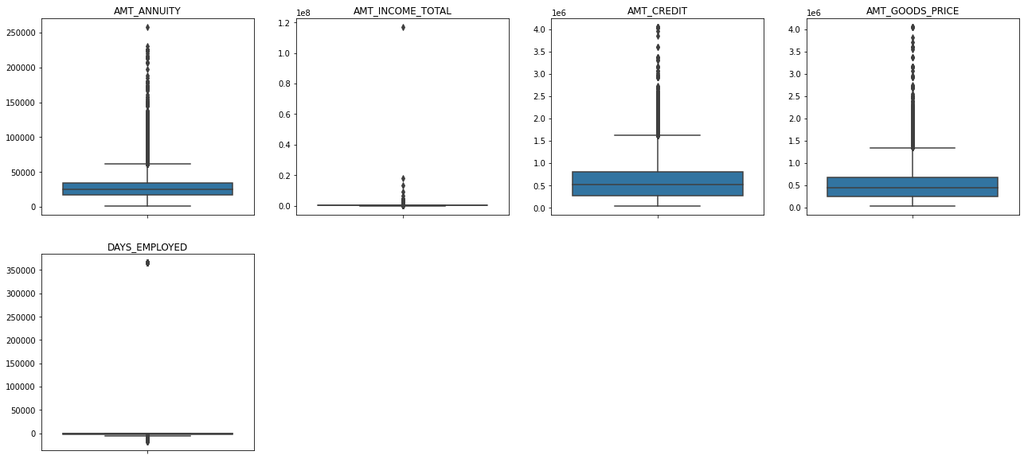

```python
plt.figure(figsize=(22,10))

outlier = ['AMT_ANNUITY','AMT_INCOME_TOTAL','AMT_CREDIT','AMT_GOODS_PRICE','DAYS_EMPLOYED']
for i in enumerate(outlier):
    plt.subplot(2,4,i[0]+1)
    sns.boxplot(y=application_train[i[1]])
    plt.title(i[1])
    plt.ylabel("")
```

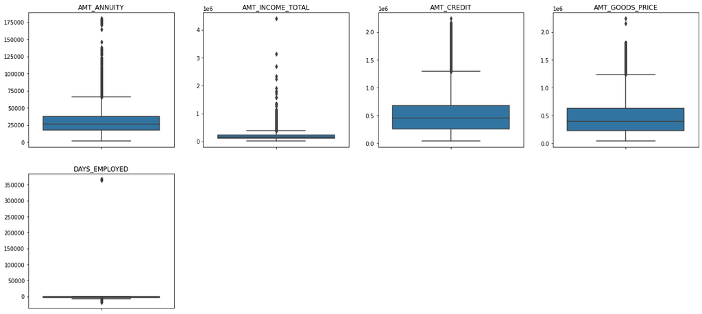

```python
plt.figure(figsize=(22,10))

outlier = ['AMT_ANNUITY','AMT_INCOME_TOTAL','AMT_CREDIT','AMT_GOODS_PRICE','DAYS_EMPLOYED']
for i in enumerate(outlier):
    plt.subplot(2,4,i[0]+1)
    sns.boxplot(y=application_test[i[1]])
    plt.title(i[1])
    plt.ylabel("")
```

```python
application_train = application_train[(application_train['DAYS_EMPLOYED'] <= 350000)]
application_test = application_test[(application_test['DAYS_EMPLOYED'] <= 350000)]
```

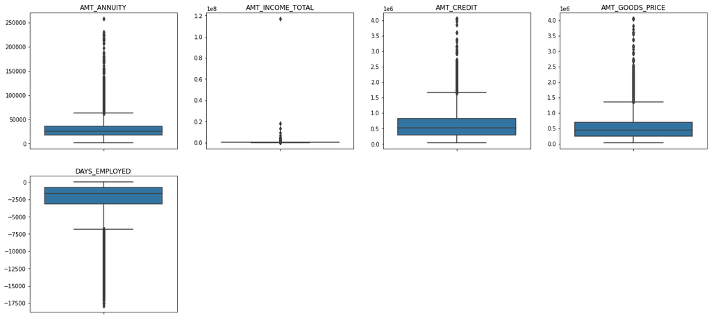

```python
plt.figure(figsize=(22,10))

outlier = ['AMT_ANNUITY','AMT_INCOME_TOTAL','AMT_CREDIT','AMT_GOODS_PRICE','DAYS_EMPLOYED']
for i in enumerate(outlier):
    plt.subplot(2,4,i[0]+1)
    sns.boxplot(y=application_train[i[1]])
    plt.title(i[1])
    plt.ylabel("")
```

```python
application_train = application_train.dropna(subset=['NAME_TYPE_SUITE', 'OBS_60_CNT_SOCIAL_CIRCLE','OCCUPATION_TYPE', 'EXT_SOURCE_2','AMT_ANNUITY'])
```

```python
application_test = application_test.dropna(subset=['NAME_TYPE_SUITE', 'OBS_60_CNT_SOCIAL_CIRCLE','AMT_ANNUITY', 'EXT_SOURCE_2'])
```

On supprime les 4 lignes contenant XNA

```python
application_train = application_train[(application_train['CODE_GENDER'] != "XNA")]
```

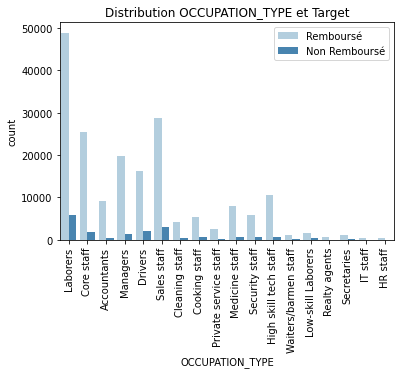

```python
plot_stats(application_train,'OCCUPATION_TYPE','Distribution OCCUPATION_TYPE et Target')
```

```python
# Suppression des colonnes de type *_MEDI , *_AVG
cols = [c for c in application_test.columns if c[-5:] != '_MEDI'  if c[-4:] != '_AVG']
application_test = application_test[cols]
```

```python
# Suppression des colonnes de type *_MEDI , *_AVG
cols = [c for c in application_train.columns if c[-5:] != '_MEDI'  if c[-4:] != '_AVG']
application_train = application_train[cols]
```

```python
# Suppression des nans de moins de 20 %
application_train = application_train.dropna(subset=['AMT_REQ_CREDIT_BUREAU_WEEK', 'EXT_SOURCE_3'])
```

## Bureau

```python
bureau.head()
```

|  | SK_ID_CURR | SK_ID_BUREAU | CREDIT_ACTIVE | CREDIT_CURRENCY | DAYS_CREDIT | CREDIT_DAY_OVERDUE | DAYS_CREDIT_ENDDATE | DAYS_ENDDATE_FACT | AMT_CREDIT_MAX_OVERDUE | CNT_CREDIT_PROLONG | AMT_CREDIT_SUM | AMT_CREDIT_SUM_DEBT | AMT_CREDIT_SUM_LIMIT | AMT_CREDIT_SUM_OVERDUE | CREDIT_TYPE | DAYS_CREDIT_UPDATE | AMT_ANNUITY |
| --- | --- | --- | --- | --- | --- | --- | --- | --- | --- | --- | --- | --- | --- | --- | --- | --- | --- |
| 0 | 215354 | 5714462 | Closed | currency 1 | -497 | 0 | -153.0 | -153.0 | NaN | 0 | 91323.0 | 0.0 | NaN | 0.0 | Consumer credit | -131 | NaN |
| 1 | 215354 | 5714463 | Active | currency 1 | -208 | 0 | 1075.0 | NaN | NaN | 0 | 225000.0 | 171342.0 | NaN | 0.0 | Credit card | -20 | NaN |
| 2 | 215354 | 5714464 | Active | currency 1 | -203 | 0 | 528.0 | NaN | NaN | 0 | 464323.5 | NaN | NaN | 0.0 | Consumer credit | -16 | NaN |
| 3 | 215354 | 5714465 | Active | currency 1 | -203 | 0 | NaN | NaN | NaN | 0 | 90000.0 | NaN | NaN | 0.0 | Credit card | -16 | NaN |
| 4 | 215354 | 5714466 | Active | currency 1 | -629 | 0 | 1197.0 | NaN | 77674.5 | 0 | 2700000.0 | NaN | NaN | 0.0 | Consumer credit | -21 | NaN |

```python
bureau.info(verbose=True)
```

```
<class 'pandas.core.frame.DataFrame'>
RangeIndex: 1716428 entries, 0 to 1716427
Data columns (total 17 columns):
 #   Column                  Dtype
---  ------                  -----
 0   SK_ID_CURR              int64
 1   SK_ID_BUREAU            int64
 2   CREDIT_ACTIVE           object
 3   CREDIT_CURRENCY         object
 4   DAYS_CREDIT             int64
 5   CREDIT_DAY_OVERDUE      int64
 6   DAYS_CREDIT_ENDDATE     float64
 7   DAYS_ENDDATE_FACT       float64
 8   AMT_CREDIT_MAX_OVERDUE  float64
 9   CNT_CREDIT_PROLONG      int64
 10  AMT_CREDIT_SUM          float64
 11  AMT_CREDIT_SUM_DEBT     float64
 12  AMT_CREDIT_SUM_LIMIT    float64
 13  AMT_CREDIT_SUM_OVERDUE  float64
 14  CREDIT_TYPE             object
 15  DAYS_CREDIT_UPDATE      int64
 16  AMT_ANNUITY             float64
dtypes: float64(8), int64(6), object(3)
memory usage: 222.6+ MB
```

```
Number of columns having NaN values: 7 columns
```

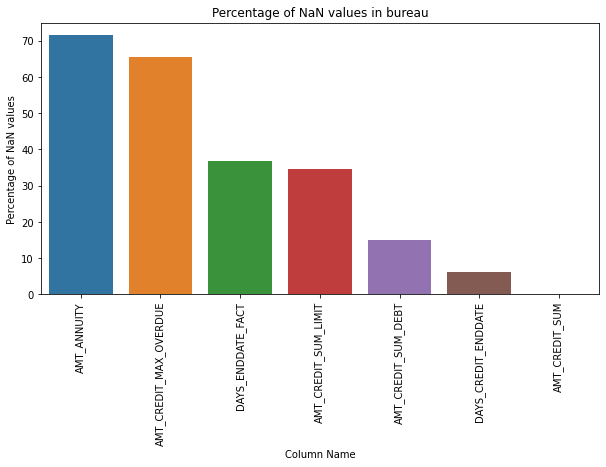

```python
plot_nan_percent(nan_df_create(bureau), 'bureau', tight_layout = False, figsize = (10,5))
```

Sur 17 variables, 7 contiennent des valeurs NaN. Les valeurs NaN les plus élevées sont observées avec la colonne AMT_ANNUITY qui a plus de 70% de valeurs manquantes. On peut supprimer les lignes contenant des nans de moins de 20%.

```python
bureau = bureau.dropna(subset=['AMT_CREDIT_SUM', 'DAYS_CREDIT_ENDDATE','AMT_CREDIT_SUM_DEBT'])
```

### Merging the TARGETS from application_train to bureau table.

```python
bureau_merged = application_train.iloc[:,:2].merge(bureau, on = 'SK_ID_CURR', how = 'left')
```

```python
bureau_merged
```

|  | SK_ID_CURR | TARGET | SK_ID_BUREAU | CREDIT_ACTIVE | CREDIT_CURRENCY | DAYS_CREDIT | CREDIT_DAY_OVERDUE | DAYS_CREDIT_ENDDATE | DAYS_ENDDATE_FACT | AMT_CREDIT_MAX_OVERDUE | CNT_CREDIT_PROLONG | AMT_CREDIT_SUM | AMT_CREDIT_SUM_DEBT | AMT_CREDIT_SUM_LIMIT | AMT_CREDIT_SUM_OVERDUE | CREDIT_TYPE | DAYS_CREDIT_UPDATE | AMT_ANNUITY |
| --- | --- | --- | --- | --- | --- | --- | --- | --- | --- | --- | --- | --- | --- | --- | --- | --- | --- | --- |
| 0 | 100002 | 1 | 6158906.0 | Closed | currency 1 | -1437.0 | 0.0 | -1072.0 | -1185.0 | 0.000 | 0.0 | 135000.0 | 0.00 | 0.0 | 0.0 | Consumer credit | -1185.0 | 0.0 |
| 1 | 100002 | 1 | 6158908.0 | Closed | currency 1 | -645.0 | 0.0 | 85.0 | -36.0 | 5043.645 | 0.0 | 120735.0 | 0.00 | 0.0 | 0.0 | Consumer credit | -34.0 | 0.0 |
| 2 | 100002 | 1 | 6158903.0 | Active | currency 1 | -1042.0 | 0.0 | 780.0 | NaN | NaN | 0.0 | 450000.0 | 245781.00 | 0.0 | 0.0 | Consumer credit | -7.0 | 0.0 |
| 3 | 100004 | 0 | 6829133.0 | Closed | currency 1 | -1326.0 | 0.0 | -595.0 | -683.0 | NaN | 0.0 | 94500.0 | 0.00 | 0.0 | 0.0 | Consumer credit | -682.0 | NaN |
| 4 | 100004 | 0 | 6829134.0 | Closed | currency 1 | -408.0 | 0.0 | -382.0 | -382.0 | 0.000 | 0.0 | 94537.8 | 0.00 | 0.0 | 0.0 | Consumer credit | -382.0 | NaN |
| ... | ... | ... | ... | ... | ... | ... | ... | ... | ... | ... | ... | ... | ... | ... | ... | ... | ... | ... |
| 784144 | 456255 | 0 | 5126330.0 | Closed | currency 1 | -1021.0 | 0.0 | -959.0 | -959.0 | NaN | 0.0 | 22995.0 | 0.00 | NaN | 0.0 | Consumer credit | -953.0 | 3244.5 |
| 784145 | 456255 | 0 | 5126331.0 | Active | currency 1 | -1020.0 | 0.0 | 806.0 | NaN | NaN | 0.0 | 810000.0 | 595102.50 | NaN | 0.0 | Consumer credit | -8.0 | 0.0 |
| 784146 | 456255 | 0 | 5126332.0 | Active | currency 1 | -378.0 | 0.0 | 27320.0 | NaN | NaN | 0.0 | 90000.0 | 61060.50 | NaN | 0.0 | Credit card | -11.0 | NaN |
| 784147 | 456255 | 0 | 5126333.0 | Active | currency 1 | -363.0 | 0.0 | 1463.0 | NaN | 0.000 | 0.0 | 436032.0 | 363573.54 | 0.0 | 0.0 | Consumer credit | -25.0 | 0.0 |
| 784148 | 456255 | 0 | 5126334.0 | Active | currency 1 | -451.0 | 0.0 | 279.0 | NaN | 15439.905 | 0.0 | 450000.0 | 191005.47 | 0.0 | 0.0 | Consumer credit | -55.0 | 3244.5 |

784149 rows × 18 columns

[figure not shown]

```python
plot_stats(bureau_merged, 'CREDIT_ACTIVE', 'Distribution des clients par éducation')
```

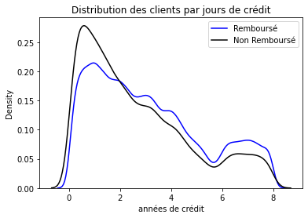

```python
sns.kdeplot(bureau_merged[bureau_merged['TARGET'] == 0]['DAYS_CREDIT'] / -365, label = 'Remboursé', color='b')
sns.kdeplot(bureau_merged[bureau_merged['TARGET'] == 1]['DAYS_CREDIT'] / -365, label = 'Non Remboursé', color='black')
plt.legend()

plt.xlabel('années de crédit')
plt.ylabel('Density')
plt.title('Distribution des clients par jours de crédit')
plt.show()
```

Selon le graphique si le temps de prêts est moins, il y a plus tendence que c'est défaillant.

## bureau_balance

```python
bureau_balance.head()
```

|  | SK_ID_BUREAU | MONTHS_BALANCE | STATUS |
| --- | --- | --- | --- |
| 0 | 5715448 | 0 | C |
| 1 | 5715448 | -1 | C |
| 2 | 5715448 | -2 | C |
| 3 | 5715448 | -3 | C |
| 4 | 5715448 | -4 | C |

```python
bureau_balance.info(verbose=True)
```

```
<class 'pandas.core.frame.DataFrame'>
RangeIndex: 27299925 entries, 0 to 27299924
Data columns (total 3 columns):
 #   Column          Dtype
---  ------          -----
 0   SK_ID_BUREAU    int64
 1   MONTHS_BALANCE  int64
 2   STATUS          object
dtypes: int64(2), object(1)
memory usage: 624.8+ MB
```

```python
plot_nan_percent(nan_df_create(bureau_balance), 'bureau_balance', tight_layout = False, figsize = (10,5))
```

```
The dataframe bureau_balance does not contain any NaN values.
```

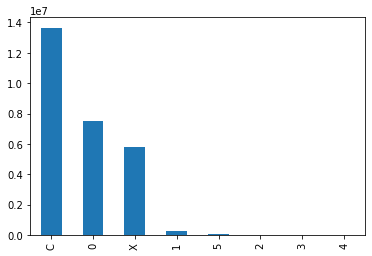

```python
bureau_balance['STATUS'].value_counts().plot(kind='bar')
```

There are 8 unique values for the STATUS which are encoded. Each of them have a special meaning.

C means closed, X means status unknown, 0 means no DPD, 1 means maximal did during month between 1-30, 2 means DPD 31-60,… 5 means DPD 120+ or sold or written off.

## previous_application

```python
previous_application.head()
```

|  | SK_ID_PREV | SK_ID_CURR | NAME_CONTRACT_TYPE | AMT_ANNUITY | AMT_APPLICATION | AMT_CREDIT | AMT_DOWN_PAYMENT | AMT_GOODS_PRICE | WEEKDAY_APPR_PROCESS_START | HOUR_APPR_PROCESS_START | FLAG_LAST_APPL_PER_CONTRACT | NFLAG_LAST_APPL_IN_DAY | RATE_DOWN_PAYMENT | RATE_INTEREST_PRIMARY | RATE_INTEREST_PRIVILEGED | NAME_CASH_LOAN_PURPOSE | NAME_CONTRACT_STATUS | DAYS_DECISION | NAME_PAYMENT_TYPE | CODE_REJECT_REASON | NAME_TYPE_SUITE | NAME_CLIENT_TYPE | NAME_GOODS_CATEGORY | NAME_PORTFOLIO | NAME_PRODUCT_TYPE | CHANNEL_TYPE | SELLERPLACE_AREA | NAME_SELLER_INDUSTRY | CNT_PAYMENT | … |
| --- | --- | --- | --- | --- | --- | --- | --- | --- | --- | --- | --- | --- | --- | --- | --- | --- | --- | --- | --- | --- | --- | --- | --- | --- | --- | --- | --- | --- | --- | --- |
| 0 | 2030495 | 271877 | Consumer loans | 1730.430 | 17145.0 | 17145.0 | 0.0 | 17145.0 | SATURDAY | 15 | Y | 1 | 0.0 | 0.182832 | 0.867336 | XAP | Approved | -73 | Cash through the bank | XAP | NaN | Repeater | Mobile | POS | XNA | Country-wide | 35 | Connectivity | 12.0 | … |
| 1 | 2802425 | 108129 | Cash loans | 25188.615 | 607500.0 | 679671.0 | NaN | 607500.0 | THURSDAY | 11 | Y | 1 | NaN | NaN | NaN | XNA | Approved | -164 | XNA | XAP | Unaccompanied | Repeater | XNA | Cash | x-sell | Contact center | -1 | XNA | 36.0 | … |
| 2 | 2523466 | 122040 | Cash loans | 15060.735 | 112500.0 | 136444.5 | NaN | 112500.0 | TUESDAY | 11 | Y | 1 | NaN | NaN | NaN | XNA | Approved | -301 | Cash through the bank | XAP | Spouse, partner | Repeater | XNA | Cash | x-sell | Credit and cash offices | -1 | XNA | 12.0 | … |
| 3 | 2819243 | 176158 | Cash loans | 47041.335 | 450000.0 | 470790.0 | NaN | 450000.0 | MONDAY | 7 | Y | 1 | NaN | NaN | NaN | XNA | Approved | -512 | Cash through the bank | XAP | NaN | Repeater | XNA | Cash | x-sell | Credit and cash offices | -1 | XNA | 12.0 | … |
| 4 | 1784265 | 202054 | Cash loans | 31924.395 | 337500.0 | 404055.0 | NaN | 337500.0 | THURSDAY | 9 | Y | 1 | NaN | NaN | NaN | Repairs | Refused | -781 | Cash through the bank | HC | NaN | Repeater | XNA | Cash | walk-in | Credit and cash offices | -1 | XNA | 24.0 | … |

```python
previous_application.info(verbose=True)
```

```
<class 'pandas.core.frame.DataFrame'>
RangeIndex: 1670214 entries, 0 to 1670213
Data columns (total 37 columns):
 #   Column                       Non-Null Count    Dtype
---  ------                       --------------    -----
 0   SK_ID_PREV                   1670214 non-null  int64
 1   SK_ID_CURR                   1670214 non-null  int64
 2   NAME_CONTRACT_TYPE           1670214 non-null  object
 3   AMT_ANNUITY                  1297979 non-null  float64
 4   AMT_APPLICATION              1670214 non-null  float64
 5   AMT_CREDIT                   1670213 non-null  float64
 6   AMT_DOWN_PAYMENT             774370 non-null   float64
 7   AMT_GOODS_PRICE              1284699 non-null  float64
 8   WEEKDAY_APPR_PROCESS_START   1670214 non-null  object
 9   HOUR_APPR_PROCESS_START      1670214 non-null  int64
```

[output cut: 29 more lines]

```
Number of columns having NaN values: 16 columns
```

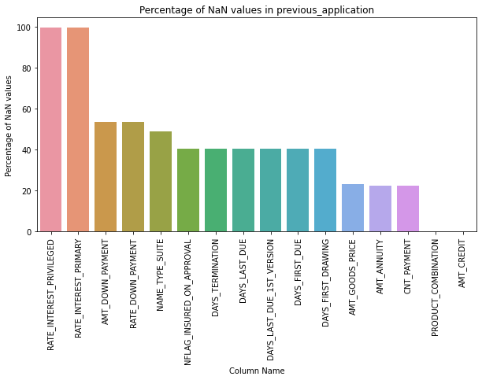

```python
plot_nan_percent(nan_df_create(previous_application), 'previous_application', tight_layout = False, figsize = (10,5))
```

Sur 37 variables, 16 contiennent des valeurs NaN dont 2 de plus de 98%. On va donc supprimer les variables de plus de 98%

```python
previous_application = remove_missing_columns(previous_application, 95)
```

```
There are 2 columns with greater than 95% missing values.
```

On supprime les lignes contenant des nans de moins de 20%.

```python
previous_application = previous_application.dropna(subset=['AMT_CREDIT', 'PRODUCT_COMBINATION'])
```

## POS_CASH_balance

```python
POS_CASH_balance.head()
```

|  | SK_ID_PREV | SK_ID_CURR | MONTHS_BALANCE | CNT_INSTALMENT | CNT_INSTALMENT_FUTURE | NAME_CONTRACT_STATUS | SK_DPD | SK_DPD_DEF |
| --- | --- | --- | --- | --- | --- | --- | --- | --- |
| 0 | 1803195 | 182943 | -31 | 48.0 | 45.0 | Active | 0 | 0 |
| 1 | 1715348 | 367990 | -33 | 36.0 | 35.0 | Active | 0 | 0 |
| 2 | 1784872 | 397406 | -32 | 12.0 | 9.0 | Active | 0 | 0 |
| 3 | 1903291 | 269225 | -35 | 48.0 | 42.0 | Active | 0 | 0 |
| 4 | 2341044 | 334279 | -35 | 36.0 | 35.0 | Active | 0 | 0 |

```python
POS_CASH_balance.info(verbose=True)
```

```
<class 'pandas.core.frame.DataFrame'>
RangeIndex: 10001358 entries, 0 to 10001357
Data columns (total 8 columns):
 #   Column                 Dtype
---  ------                 -----
 0   SK_ID_PREV             int64
 1   SK_ID_CURR             int64
 2   MONTHS_BALANCE         int64
 3   CNT_INSTALMENT         float64
 4   CNT_INSTALMENT_FUTURE  float64
 5   NAME_CONTRACT_STATUS   object
 6   SK_DPD                 int64
 7   SK_DPD_DEF             int64
dtypes: float64(2), int64(5), object(1)
memory usage: 610.4+ MB
```

```
Number of columns having NaN values: 2 columns
```

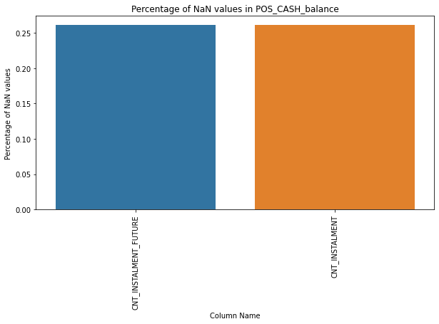

```python
plot_nan_percent(nan_df_create(POS_CASH_balance), 'POS_CASH_balance', tight_layout = False, figsize = (10,5))
```

Sur 8 variables, 2 contiennent des valeurs NaN de moins de 1%. On peut donc les supprimer

```python
# Reset index after drop
POS_CASH_balance=POS_CASH_balance.dropna().reset_index(drop=True)
POS_CASH_balance.shape
```

```
(9975174, 8)
```

## installments_payments

```python
installments_payments.head()
```

|  | SK_ID_PREV | SK_ID_CURR | NUM_INSTALMENT_VERSION | NUM_INSTALMENT_NUMBER | DAYS_INSTALMENT | DAYS_ENTRY_PAYMENT | AMT_INSTALMENT | AMT_PAYMENT |
| --- | --- | --- | --- | --- | --- | --- | --- | --- |
| 0 | 1054186 | 161674 | 1.0 | 6 | -1180.0 | -1187.0 | 6948.360 | 6948.360 |
| 1 | 1330831 | 151639 | 0.0 | 34 | -2156.0 | -2156.0 | 1716.525 | 1716.525 |
| 2 | 2085231 | 193053 | 2.0 | 1 | -63.0 | -63.0 | 25425.000 | 25425.000 |
| 3 | 2452527 | 199697 | 1.0 | 3 | -2418.0 | -2426.0 | 24350.130 | 24350.130 |
| 4 | 2714724 | 167756 | 1.0 | 2 | -1383.0 | -1366.0 | 2165.040 | 2160.585 |

```python
installments_payments.info(verbose=True)
```

```
<class 'pandas.core.frame.DataFrame'>
RangeIndex: 13605401 entries, 0 to 13605400
Data columns (total 8 columns):
 #   Column                  Dtype
---  ------                  -----
 0   SK_ID_PREV              int64
 1   SK_ID_CURR              int64
 2   NUM_INSTALMENT_VERSION  float64
 3   NUM_INSTALMENT_NUMBER   int64
 4   DAYS_INSTALMENT         float64
 5   DAYS_ENTRY_PAYMENT      float64
 6   AMT_INSTALMENT          float64
 7   AMT_PAYMENT             float64
dtypes: float64(5), int64(3)
memory usage: 830.4 MB
```

```
Number of columns having NaN values: 2 columns
```

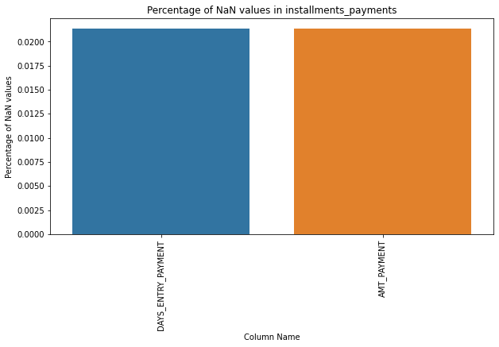

```python
plot_nan_percent(nan_df_create(installments_payments), 'installments_payments', tight_layout = False, figsize = (10,5))
```

Sur 8 variables, 2 contiennent des valeurs NaN de moins de 1%. On peut donc les supprimer

```python
# Reset index after drop
installments_payments=installments_payments.dropna().reset_index(drop=True)
```

```python
installments_payments.shape
```

```
(13602496, 8)
```

## credit_card_balance

```python
credit_card_balance.head()
```

|  | SK_ID_PREV | SK_ID_CURR | MONTHS_BALANCE | AMT_BALANCE | AMT_CREDIT_LIMIT_ACTUAL | AMT_DRAWINGS_ATM_CURRENT | AMT_DRAWINGS_CURRENT | AMT_DRAWINGS_OTHER_CURRENT | AMT_DRAWINGS_POS_CURRENT | AMT_INST_MIN_REGULARITY | AMT_PAYMENT_CURRENT | AMT_PAYMENT_TOTAL_CURRENT | AMT_RECEIVABLE_PRINCIPAL | AMT_RECIVABLE | AMT_TOTAL_RECEIVABLE | CNT_DRAWINGS_ATM_CURRENT | CNT_DRAWINGS_CURRENT | CNT_DRAWINGS_OTHER_CURRENT | CNT_DRAWINGS_POS_CURRENT | CNT_INSTALMENT_MATURE_CUM | NAME_CONTRACT_STATUS | SK_DPD | SK_DPD_DEF |
| --- | --- | --- | --- | --- | --- | --- | --- | --- | --- | --- | --- | --- | --- | --- | --- | --- | --- | --- | --- | --- | --- | --- | --- |
| 0 | 2562384 | 378907 | -6 | 56.970 | 135000 | 0.0 | 877.5 | 0.0 | 877.5 | 1700.325 | 1800.0 | 1800.0 | 0.000 | 0.000 | 0.000 | 0.0 | 1 | 0.0 | 1.0 | 35.0 | Active | 0 | 0 |
| 1 | 2582071 | 363914 | -1 | 63975.555 | 45000 | 2250.0 | 2250.0 | 0.0 | 0.0 | 2250.000 | 2250.0 | 2250.0 | 60175.080 | 64875.555 | 64875.555 | 1.0 | 1 | 0.0 | 0.0 | 69.0 | Active | 0 | 0 |
| 2 | 1740877 | 371185 | -7 | 31815.225 | 450000 | 0.0 | 0.0 | 0.0 | 0.0 | 2250.000 | 2250.0 | 2250.0 | 26926.425 | 31460.085 | 31460.085 | 0.0 | 0 | 0.0 | 0.0 | 30.0 | Active | 0 | 0 |
| 3 | 1389973 | 337855 | -4 | 236572.110 | 225000 | 2250.0 | 2250.0 | 0.0 | 0.0 | 11795.760 | 11925.0 | 11925.0 | 224949.285 | 233048.970 | 233048.970 | 1.0 | 1 | 0.0 | 0.0 | 10.0 | Active | 0 | 0 |
| 4 | 1891521 | 126868 | -1 | 453919.455 | 450000 | 0.0 | 11547.0 | 0.0 | 11547.0 | 22924.890 | 27000.0 | 27000.0 | 443044.395 | 453919.455 | 453919.455 | 0.0 | 1 | 0.0 | 1.0 | 101.0 | Active | 0 | 0 |

```python
credit_card_balance.info(verbose=True)
```

```
<class 'pandas.core.frame.DataFrame'>
RangeIndex: 3840312 entries, 0 to 3840311
Data columns (total 23 columns):
 #   Column                      Dtype
---  ------                      -----
 0   SK_ID_PREV                  int64
 1   SK_ID_CURR                  int64
 2   MONTHS_BALANCE              int64
 3   AMT_BALANCE                 float64
 4   AMT_CREDIT_LIMIT_ACTUAL     int64
 5   AMT_DRAWINGS_ATM_CURRENT    float64
 6   AMT_DRAWINGS_CURRENT        float64
 7   AMT_DRAWINGS_OTHER_CURRENT  float64
 8   AMT_DRAWINGS_POS_CURRENT    float64
 9   AMT_INST_MIN_REGULARITY     float64
 10  AMT_PAYMENT_CURRENT         float64
 11  AMT_PAYMENT_TOTAL_CURRENT   float64
 12  AMT_RECEIVABLE_PRINCIPAL    float64
 13  AMT_RECIVABLE               float64
 14  AMT_TOTAL_RECEIVABLE        float64
 15  CNT_DRAWINGS_ATM_CURRENT    float64
 16  CNT_DRAWINGS_CURRENT        int64
 17  CNT_DRAWINGS_OTHER_CURRENT  float64
 18  CNT_DRAWINGS_POS_CURRENT    float64
 19  CNT_INSTALMENT_MATURE_CUM   float64
 20  NAME_CONTRACT_STATUS        object
 21  SK_DPD                      int64
 22  SK_DPD_DEF                  int64
dtypes: float64(15), int64(7), object(1)
memory usage: 673.9+ MB
```

```
Number of columns having NaN values: 9 columns
```

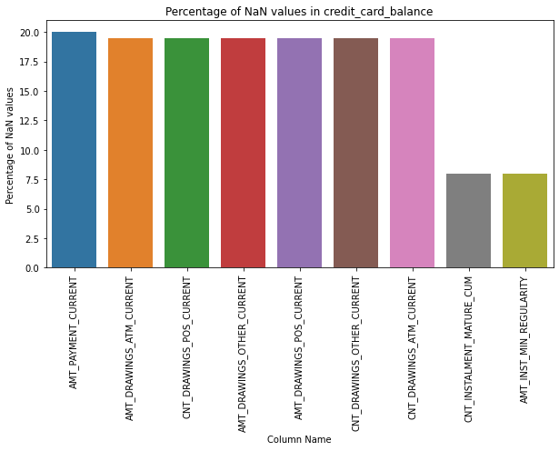

```python
plot_nan_percent(nan_df_create(credit_card_balance), 'credit_card_balance', tight_layout = False, figsize = (10,5))
```

Sur 23 variables, 9 contiennent des valeurs NaN de moins de 20%. On peut les supprimer.

```python
# Reset index after drop
credit_card_balance=credit_card_balance.dropna().reset_index(drop=True)
```

```python
credit_card_balance.shape
```

```
(3014276, 23)
```

## sample_submission

```python
sample_submission.head()
```

|  | SK_ID_CURR | TARGET |
| --- | --- | --- |
| 0 | 100001 | 0.5 |
| 1 | 100005 | 0.5 |
| 2 | 100013 | 0.5 |
| 3 | 100028 | 0.5 |
| 4 | 100038 | 0.5 |

```python
plot_nan_percent(nan_df_create(sample_submission), 'sample_submission', tight_layout = False, figsize = (10,5))
```

```
The dataframe sample_submission does not contain any NaN values.
```

```python
sample_submission.TARGET.unique()
```

```
array([0.5])
```

```
Le jeu de données sample_submission n'est pas utile pour la suite.
```

# Feaure Engineering

## Join tables

```python
df_all = application_train_test()
df_all.shape
```

```
Train samples: 167730, test samples: 38725
```

```
(206455, 197)
```

```python
bureau_df = bureau_and_balance()
print(bureau_df.shape)
```

```
(294722, 116)
```

```python
df_all = df_all.join(bureau_df, how='left', on='SK_ID_CURR')
print(df_all.shape)
```

```
(206455, 313)
```

```python
prev = previous_applications()
df_all = df_all.join(prev, how='left', on='SK_ID_CURR')
```

```python
pos = pos_cash()
df_all = df_all.join(pos, how='left', on='SK_ID_CURR')
```

```python
installments_p = installments()
df_all = df_all.join(installments_p, how='left', on='SK_ID_CURR')
```

```python
cc = credit_card()
df_all = df_all.join(cc, how='left', on='SK_ID_CURR')
```

```python
df_all.shape
```

```
(206455, 730)
```

```python
df_clean = df_all
```

```python
df_clean.drop(['index'], axis=1, inplace= True)
```

```python
print("Le jeu de données df contient %d lignes et %d colonnes." % (df_clean.shape[0], df_clean.shape[1]))
print(f"{df_clean.duplicated().sum()} doublons et {(df_clean.isna().sum().sum() / df_clean.shape[0]/df_clean.shape[1])*100} % Nans")
```

```
Le jeu de données df contient 206455 lignes et 729 colonnes.
0 doublons et 23.49692813949665 % Nans
```

```python
df_clean.head()
```

|  | SK_ID_CURR | TARGET | CODE_GENDER | FLAG_OWN_CAR | FLAG_OWN_REALTY | CNT_CHILDREN | AMT_INCOME_TOTAL | AMT_CREDIT | AMT_ANNUITY | AMT_GOODS_PRICE | REGION_POPULATION_RELATIVE | DAYS_BIRTH | DAYS_EMPLOYED | OWN_CAR_AGE | CNT_FAM_MEMBERS | REGION_RATING_CLIENT | REGION_RATING_CLIENT_W_CITY | EXT_SOURCE_1 | EXT_SOURCE_2 | EXT_SOURCE_3 | APARTMENTS_MODE | BASEMENTAREA_MODE | YEARS_BEGINEXPLUATATION_MODE | YEARS_BUILD_MODE | COMMONAREA_MODE | ELEVATORS_MODE | ENTRANCES_MODE | FLOORSMAX_MODE | FLOORSMIN_MODE | … |
| --- | --- | --- | --- | --- | --- | --- | --- | --- | --- | --- | --- | --- | --- | --- | --- | --- | --- | --- | --- | --- | --- | --- | --- | --- | --- | --- | --- | --- | --- | --- |
| 0 | 100002 | 1.0 | 0 | 0 | 0 | 0 | 202500.0 | 406597.5 | 24700.5 | 351000.0 | 0.018801 | -9461 | -637 | NaN | 1.0 | 2 | 2 | 0.083037 | 0.262949 | 0.139376 | 0.0252 | 0.0383 | 0.9722 | 0.6341 | 0.0144 | 0.0 | 0.069 | 0.0833 | 0.125 | … |
| 1 | 100004 | 0.0 | 0 | 1 | 0 | 0 | 67500.0 | 135000.0 | 6750.0 | 135000.0 | 0.010032 | -19046 | -225 | 26.0 | 1.0 | 2 | 2 | NaN | 0.555912 | 0.729567 | NaN | NaN | NaN | NaN | NaN | NaN | NaN | NaN | NaN | … |
| 2 | 100008 | 0.0 | 0 | 0 | 0 | 0 | 99000.0 | 490495.5 | 27517.5 | 454500.0 | 0.035792 | -16941 | -1588 | NaN | 2.0 | 2 | 2 | NaN | 0.354225 | 0.621226 | NaN | NaN | NaN | NaN | NaN | NaN | NaN | NaN | NaN | … |
| 3 | 100009 | 0.0 | 1 | 1 | 0 | 1 | 171000.0 | 1560726.0 | 41301.0 | 1395000.0 | 0.035792 | -13778 | -3130 | 17.0 | 3.0 | 2 | 2 | 0.774761 | 0.724000 | 0.492060 | NaN | NaN | NaN | NaN | NaN | NaN | NaN | NaN | NaN | … |
| 4 | 100010 | 0.0 | 0 | 1 | 0 | 0 | 360000.0 | 1530000.0 | 42075.0 | 1530000.0 | 0.003122 | -18850 | -449 | 8.0 | 2.0 | 3 | 3 | NaN | 0.714279 | 0.540654 | NaN | NaN | NaN | NaN | NaN | NaN | NaN | NaN | NaN | … |

5 rows × 729 columns

```python
remove_missing_columns(df_clean, 75)
```

```
There are 133 columns with greater than 75% missing values.
```

|  | SK_ID_CURR | TARGET | CODE_GENDER | FLAG_OWN_CAR | FLAG_OWN_REALTY | CNT_CHILDREN | AMT_INCOME_TOTAL | AMT_CREDIT | AMT_ANNUITY | AMT_GOODS_PRICE | REGION_POPULATION_RELATIVE | DAYS_BIRTH | DAYS_EMPLOYED | OWN_CAR_AGE | CNT_FAM_MEMBERS | REGION_RATING_CLIENT | REGION_RATING_CLIENT_W_CITY | EXT_SOURCE_1 | EXT_SOURCE_2 | EXT_SOURCE_3 | APARTMENTS_MODE | BASEMENTAREA_MODE | YEARS_BEGINEXPLUATATION_MODE | YEARS_BUILD_MODE | COMMONAREA_MODE | ELEVATORS_MODE | ENTRANCES_MODE | FLOORSMAX_MODE | FLOORSMIN_MODE | … |
| --- | --- | --- | --- | --- | --- | --- | --- | --- | --- | --- | --- | --- | --- | --- | --- | --- | --- | --- | --- | --- | --- | --- | --- | --- | --- | --- | --- | --- | --- | --- |
| 0 | 100002 | 1.0 | 0 | 0 | 0 | 0 | 202500.0 | 406597.5 | 24700.5 | 351000.0 | 0.018801 | -9461 | -637 | NaN | 1.0 | 2 | 2 | 0.083037 | 0.262949 | 0.139376 | 0.0252 | 0.0383 | 0.9722 | 0.6341 | 0.0144 | 0.0000 | 0.0690 | 0.0833 | 0.125 | … |
| 1 | 100004 | 0.0 | 0 | 1 | 0 | 0 | 67500.0 | 135000.0 | 6750.0 | 135000.0 | 0.010032 | -19046 | -225 | 26.0 | 1.0 | 2 | 2 | NaN | 0.555912 | 0.729567 | NaN | NaN | NaN | NaN | NaN | NaN | NaN | NaN | NaN | … |
| 2 | 100008 | 0.0 | 0 | 0 | 0 | 0 | 99000.0 | 490495.5 | 27517.5 | 454500.0 | 0.035792 | -16941 | -1588 | NaN | 2.0 | 2 | 2 | NaN | 0.354225 | 0.621226 | NaN | NaN | NaN | NaN | NaN | NaN | NaN | NaN | NaN | … |
| 3 | 100009 | 0.0 | 1 | 1 | 0 | 1 | 171000.0 | 1560726.0 | 41301.0 | 1395000.0 | 0.035792 | -13778 | -3130 | 17.0 | 3.0 | 2 | 2 | 0.774761 | 0.724000 | 0.492060 | NaN | NaN | NaN | NaN | NaN | NaN | NaN | NaN | NaN | … |
| 4 | 100010 | 0.0 | 0 | 1 | 0 | 0 | 360000.0 | 1530000.0 | 42075.0 | 1530000.0 | 0.003122 | -18850 | -449 | 8.0 | 2.0 | 3 | 3 | NaN | 0.714279 | 0.540654 | NaN | NaN | NaN | NaN | NaN | NaN | NaN | NaN | NaN | … |
| ... | ... | ... | ... | ... | ... | ... | ... | ... | ... | ... | ... | ... | ... | ... | ... | ... | ... | ... | ... | ... | ... | ... | ... | ... | ... | ... | ... | ... | ... | … |
| 206450 | 456221 | NaN | 1 | 0 | 0 | 0 | 121500.0 | 412560.0 | 17473.5 | 270000.0 | 0.002042 | -19970 | -5169 | NaN | 1.0 | 3 | 3 | NaN | 0.648575 | 0.643026 | NaN | NaN | NaN | NaN | NaN | NaN | NaN | NaN | NaN | … |
| 206451 | 456222 | NaN | 1 | 0 | 1 | 2 | 157500.0 | 622413.0 | 31909.5 | 495000.0 | 0.035792 | -11186 | -1149 | NaN | 4.0 | 2 | 2 | NaN | 0.684596 | NaN | NaN | NaN | NaN | NaN | NaN | NaN | NaN | NaN | NaN | … |
| 206452 | 456223 | NaN | 1 | 1 | 0 | 1 | 202500.0 | 315000.0 | 33205.5 | 315000.0 | 0.026392 | -15922 | -3037 | 4.0 | 3.0 | 2 | 2 | 0.733503 | 0.632770 | 0.283712 | 0.1134 | 0.1415 | 0.9955 | NaN | NaN | 0.1611 | 0.1379 | 0.3333 | NaN | … |
| 206453 | 456224 | NaN | 0 | 0 | 1 | 0 | 225000.0 | 450000.0 | 25128.0 | 450000.0 | 0.018850 | -13968 | -2731 | NaN | 2.0 | 2 | 2 | 0.373090 | 0.445701 | 0.595456 | 0.1660 | 0.0750 | 0.9896 | NaN | NaN | 0.1611 | 0.0690 | 0.6250 | NaN | … |
| 206454 | 456250 | NaN | 1 | 1 | 1 | 0 | 135000.0 | 312768.0 | 24709.5 | 270000.0 | 0.006629 | -13962 | -633 | 22.0 | 2.0 | 2 | 2 | NaN | 0.456541 | 0.272134 | NaN | NaN | NaN | NaN | NaN | NaN | NaN | NaN | NaN | … |

206455 rows × 596 columns

Renommage des variables

```python
df_clean = df_clean.rename(columns = lambda x:re.sub('[^A-Za-z0-9_]+', '', x))
```

# Separation train and test data

```python
col_drop = ['TARGET']
X = df_clean[df_clean['TARGET'].notnull()].drop(col_drop, axis=1)
y = df_clean[df_clean['TARGET'].notnull()]['TARGET']
```

```python
X.shape
```

```
(167730, 728)
```

```python
y.shape
```

```
(167730,)
```

Séparation train(70 %) et test(30 %) des données

```python
X = X.set_index('SK_ID_CURR')
```

```python
# Split the data into train and test sets
X_train, X_test, y_train, y_test = train_test_split(X, y, test_size=0.3, random_state=42)
```

## Preprocessing

### Imputation des valeurs manquantes

```python
# Median imputation of missing values
imputer = SimpleImputer(missing_values=np.nan, strategy='median', verbose=0)
```

```python
X_train.replace([np.inf, -np.inf], np.nan, inplace=True)
X_test.replace([np.inf, -np.inf], np.nan, inplace=True)
```

```python
# Fit on the training data
imputer.fit(X_train)
```

```
SimpleImputer(strategy='median', verbose=0)
```

```python
# Transform training data
X_train_preproc = imputer.transform(X_train)
X_test_preproc = imputer.transform(X_test)
```

### Scale

```python
# Scale each feature to 0-1
scaler = MinMaxScaler(feature_range = (0, 1))
# Repeat with the scaler
scaler.fit(X_train_preproc)
X_train_preproc = scaler.transform(X_train_preproc)
X_test_preproc = scaler.transform(X_test_preproc)
X_train = pd.DataFrame(scaler.transform(X_train_preproc),
                      index=X_train.index,
                      columns=X_train.columns)

X_test = pd.DataFrame(scaler.transform(X_test_preproc),
                     index=X_test.index,
                     columns=X_test.columns)
```

```python
X_train
```

| SK_ID_CURR | CODE_GENDER | FLAG_OWN_CAR | FLAG_OWN_REALTY | CNT_CHILDREN | AMT_INCOME_TOTAL | AMT_CREDIT | AMT_ANNUITY | AMT_GOODS_PRICE | REGION_POPULATION_RELATIVE | DAYS_BIRTH | DAYS_EMPLOYED | OWN_CAR_AGE | CNT_FAM_MEMBERS | REGION_RATING_CLIENT | REGION_RATING_CLIENT_W_CITY | EXT_SOURCE_1 | EXT_SOURCE_2 | EXT_SOURCE_3 | APARTMENTS_MODE | BASEMENTAREA_MODE | YEARS_BEGINEXPLUATATION_MODE | YEARS_BUILD_MODE | COMMONAREA_MODE | ELEVATORS_MODE | ENTRANCES_MODE | FLOORSMAX_MODE | FLOORSMIN_MODE | LANDAREA_MODE | LIVINGAPARTMENTS_MODE | … |
| --- | --- | --- | --- | --- | --- | --- | --- | --- | --- | --- | --- | --- | --- | --- | --- | --- | --- | --- | --- | --- | --- | --- | --- | --- | --- | --- | --- | --- | --- | --- |
| 423876 | 0.0 | 0.0 | 0.0 | 0.00000 | -0.000227 | -0.011236 | -0.007733 | -0.011236 | 1.748636 | 1.438059 | 1.000034 | 0.001087 | -0.049861 | -0.25 | -0.25 | 0.484969 | 0.593322 | 0.592612 | 0.1229 | 0.1546 | 0.9836 | 0.7648 | 0.0190 | 0.0000 | 0.2759 | 0.1667 | 0.2083 | 0.0978 | 0.0771 | … |
| 364563 | 0.0 | 1.0 | 0.0 | 0.00554 | -0.000227 | -0.011236 | -0.007733 | -0.011236 | 13.886308 | 1.438059 | 1.000051 | 0.001328 | -0.044321 | -0.50 | -0.50 | 0.900045 | 0.982544 | 0.840894 | 0.0189 | 0.0057 | 0.9384 | 0.1898 | 0.0305 | 0.0000 | 0.0345 | 0.1250 | 0.0417 | 0.0460 | 0.0147 | … |
| 397002 | 1.0 | 1.0 | 1.0 | 0.00277 | -0.000227 | -0.011236 | -0.007732 | -0.011236 | 3.888046 | 1.438073 | 1.000054 | 0.001691 | -0.047091 | 0.00 | -0.25 | 0.234015 | 0.317122 | 0.251911 | 0.3204 | 0.2551 | 0.9886 | 0.8497 | 0.0829 | 0.3625 | 0.3103 | 0.3750 | 0.4167 | 0.1718 | 0.2792 | … |
| 393346 | 1.0 | 0.0 | 0.0 | 0.00000 | -0.000227 | -0.011236 | -0.007733 | -0.011236 | 3.576873 | 1.438057 | 1.000037 | 0.001087 | -0.049861 | -0.25 | -0.25 | 0.532816 | 0.528659 | 1.029126 | 0.0840 | 0.0747 | 0.9816 | 0.7648 | 0.0190 | 0.0000 | 0.1379 | 0.1667 | 0.2083 | 0.0460 | 0.0771 | … |
| 415034 | 1.0 | 0.0 | 0.0 | 0.00277 | -0.000227 | -0.011236 | -0.007733 | -0.011236 | 1.262960 | 1.438076 | 1.000050 | 0.001087 | -0.047091 | -0.25 | -0.25 | 0.532816 | 0.180216 | 0.208468 | 0.0840 | 0.0747 | 0.9816 | 0.7648 | 0.0190 | 0.0000 | 0.1379 | 0.1667 | 0.2083 | 0.0460 | 0.0771 | … |
| ... | ... | ... | ... | ... | ... | ... | ... | ... | ... | ... | ... | ... | ... | ... | ... | ... | ... | ... | ... | ... | ... | ... | ... | ... | ... | ... | ... | ... | ... | … |
| 355011 | 0.0 | 0.0 | 0.0 | 0.00000 | -0.000227 | -0.011236 | -0.007732 | -0.011236 | 13.886308 | 1.438070 | 1.000042 | 0.001087 | -0.052632 | -0.50 | -0.50 | 0.532816 | 0.766269 | 0.388124 | 0.0840 | 0.0747 | 0.9801 | 0.7648 | 0.0190 | 0.0000 | 0.1379 | 0.1667 | 0.2083 | 0.0460 | 0.0771 | … |
| 320824 | 0.0 | 1.0 | 0.0 | 0.00277 | -0.000227 | -0.011236 | -0.007733 | -0.011236 | 4.747246 | 1.438057 | 1.000048 | 0.001087 | -0.047091 | -0.25 | -0.25 | 0.728268 | 0.929745 | 0.785458 | 0.0840 | 0.0747 | 0.9816 | 0.7648 | 0.0190 | 0.0000 | 0.1379 | 0.1667 | 0.2083 | 0.0460 | 0.0771 | … |
| 380223 | 1.0 | 0.0 | 1.0 | 0.00000 | -0.000227 | -0.011236 | -0.007733 | -0.011236 | 0.871098 | 1.438059 | 1.000034 | 0.001087 | -0.052632 | -0.25 | -0.25 | 0.532816 | 0.133272 | 0.635500 | 0.0588 | 0.0968 | 0.9791 | 0.7648 | 0.0190 | 0.0000 | 0.1379 | 0.1667 | 0.2083 | 0.0460 | 0.0771 | … |
| 412029 | 1.0 | 1.0 | 0.0 | 0.00277 | -0.000227 | -0.011236 | -0.007732 | -0.011236 | 3.528422 | 1.438069 | 1.000053 | 0.000362 | -0.047091 | -0.25 | -0.25 | 0.813795 | 0.988323 | 0.838901 | 0.0882 | 0.0895 | 0.9667 | 0.5622 | 0.0118 | 0.0000 | 0.1379 | 0.0833 | 0.1250 | 0.0255 | 0.0771 | … |
| 359375 | 0.0 | 1.0 | 0.0 | 0.00554 | -0.000227 | -0.011236 | -0.007733 | -0.011236 | 1.821218 | 1.438061 | 1.000045 | 0.001570 | -0.044321 | -0.25 | -0.25 | 0.532816 | 0.598713 | 0.392005 | 0.2017 | 0.0755 | 0.9836 | 0.7844 | 0.1258 | 0.2417 | 0.1034 | 0.6250 | 0.6667 | 0.0609 | 0.1763 | … |

117411 rows × 727 columns

# Modélisation

On va mettre en place une comparaison d'algorithmes de classification, déterminer celui qui sera le plus adapté à la problématique (en prenant en compte le fait qu'il y ait un déséquilibre de TARGET, Il y a beaucoup plus de prêts remboursés à temps que de prêts non remboursés.) tout en montrant l'importance des features puis séléctionner les features pertinentes pour les visualisations sur notre dashboard.

## Classifiers

```python
classifiers = {
    "LogisticRegression": LogisticRegression(solver = 'lbfgs', max_iter=1000),
    "LGBMClassifier": LGBMClassifier(objective='binary', random_state=42),
    "XGBClassifier": XGBClassifier(),
    "KNeighborsClassifier": KNeighborsClassifier(),
    "RandomForestClassifier": RandomForestClassifier(random_state = 42, class_weight="balanced"),
    "AdaBoostClassifier": AdaBoostClassifier()
}
```

**Métriques**

Les algorithmes sont comparés par les métriques suivantes :

Accuracy_score : le ratio entre le nombre total de prédictions correctes et le nombre total de prédictions (c'est la justesse de la prédiction).

Precision : Le ratio entre les vrais positifs et tous les positifs

Recall : La moyenne harmonique de Precision et du Recall. Un bon score F1 indique une bonne Precision et une bonne valeur de Recall

F1_score : Ce coefficient est une moyenne de la précision et du rappel, il est calculé à partir de la précision et du rappel du test, où la précision est le nombre de vrais résultats positifs divisé par le nombre de tous les résultats positifs, y compris ceux qui ne sont pas identifiés correctement, et le rappel est le nombre de vrais résultats positifs divisé par le nombre de tous les échantillons qui auraient dû être identifiés comme positifs. La précision est également connue sous le nom de valeur prédictive positive et le rappel est également connu sous le nom de sensibilité dans la classification binaire diagnostique.

AUC : Aire sous la courbe ROC est la mesure de la capacité d'un classifieur à distinguer les classes. Plus l'AUC est élevée, plus la performance du modèle à distinguer les classes positives et négatives est bonne. Matrice de confusion"

F-beta score: Le F-beta score applique des pondérations supplémentaires, valorisant l'une de la précision ou du rappel plus que l'autre. Plus le beta est petit, plus on valorise la précision, plus le beta est grand, plus on valorise le recall.

TP (True Positives) : les cas où la prédiction est positive, et où la valeur réelle est effectivement positive.

TN (True Negatives) : les cas où la prédiction est négative, et où la valeur réelle est effectivement négative.

FP (False Positive) : les cas où la prédiction est positive, mais où la valeur réelle est négative.

FN (False Negative) : les cas où la prédiction est négative, mais où la valeur réelle est positive.

```python
y_train.value_counts(normalize=True)
```

```
0.0    0.915545
1.0    0.084455
Name: TARGET, dtype: float64
```

### Dummy Classifier

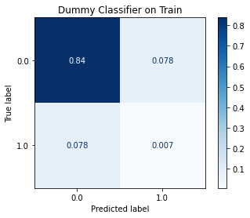

```python
clf_dc = DummyClassifier(strategy='stratified')
clf_dc.fit(X_train, y_train)
y_pred = clf_dc.predict(X_train)
cm = plot_confusion_matrix(estimator=clf_dc, X=X_train, y_true=y_pred,
                      normalize='all', cmap='Blues')
plt.grid(False)

cm.ax_.set_title("Dummy Classifier on Train")
```

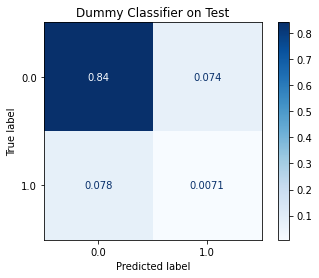

```python
clf_dc = DummyClassifier(strategy='stratified')
clf_dc.fit(X_train, y_train)
y_pred = clf_dc.predict(X_test)
cm = plot_confusion_matrix(estimator=clf_dc, X=X_test, y_true=y_pred,
                      normalize='all', cmap='Blues')
plt.grid(False)

cm.ax_.set_title("Dummy Classifier on Test")
```

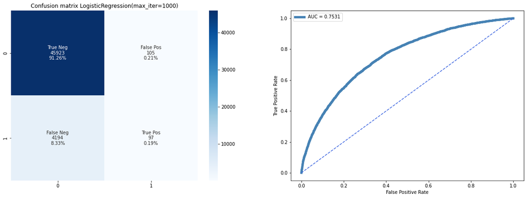

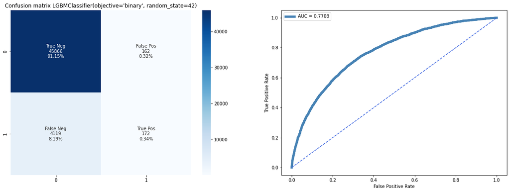

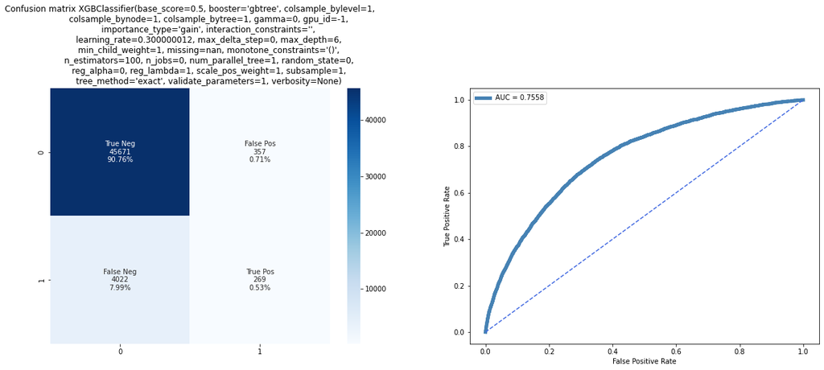

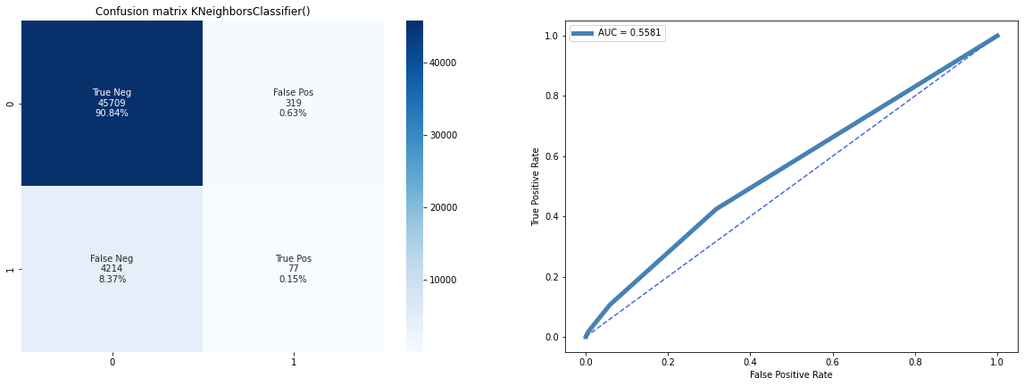

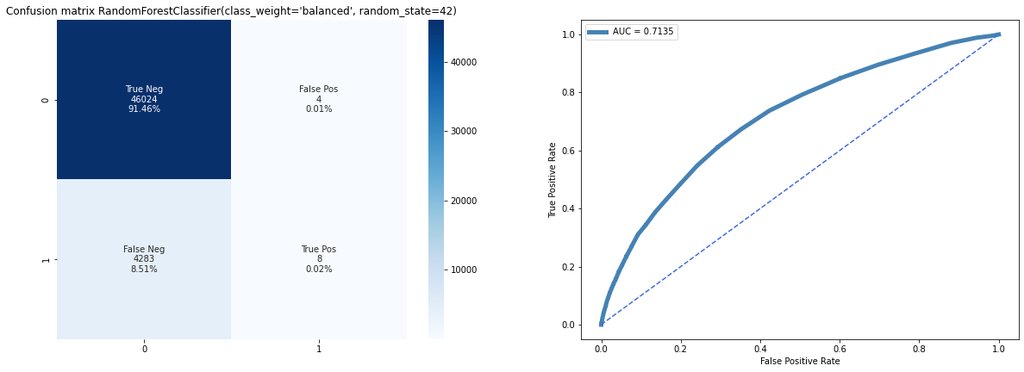

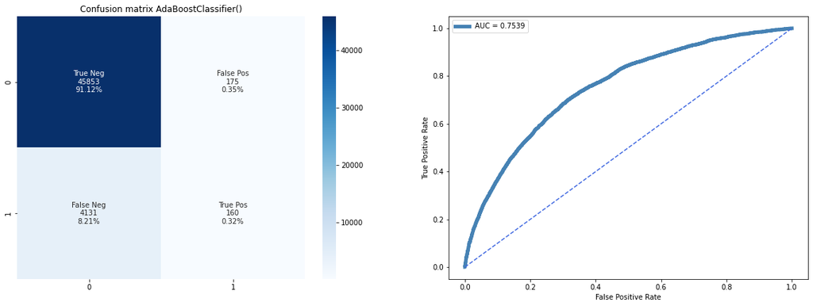

```python
df_models = pd.DataFrame(columns=['model', 'run_time', 'Score test', 'Score train', 'accuracy', 'precision', 'recall', 'f1_score', 'roc auc score', 'fpr', 'tpr','fbeta'])

for key in classifiers:

    start_time = time.time()
    classifier = classifiers[key]
    model = classifier.fit(X_train, y_train)

    y_pred = model.predict(X_test)
    y_pred_proba = model.predict_proba(X_test)[:,1]

    fig = plt.figure(figsize=(20,15))

    plt.subplot(221)
    # Compute confusion matrix
    cnf_matrix = confusion_matrix(y_test, y_pred)
    group_names = ['True Neg', 'False Pos', 'False Neg', 'True Pos']
    group_counts = ["{0:0.0f}".format(value) for value in cnf_matrix.flatten()]
    group_percentages = ["{0:.2%}".format(value) for value in cnf_matrix.flatten()/np.sum(cnf_matrix)]

    labels = [f"{v1}\n{v2}\n{v3}" for v1, v2, v3 in zip(group_names,group_counts,group_percentages)]
    labels = np.asarray(labels).reshape(2,2)
    sns.heatmap(cnf_matrix, annot=labels, fmt="", cmap='Blues')

    plt.title(f'Confusion matrix {model}')


    plt.subplot(222)
    fpr,tpr,_ = roc_curve(y_test, y_pred_proba)
    plt.plot(fpr, tpr, color='steelblue', linewidth=5, label='AUC = %0.4f' %roc_auc_score(y_test, y_pred_proba))
    plt.plot([0, 1], [0, 1], color='royalblue', linestyle='--')
    plt.xlabel('False Positive Rate')
    plt.ylabel('True Positive Rate')
    plt.legend()

    plt.show()

    row = {'model': key,
           'run_time': format(round((time.time() - start_time)/60,2)),
           'Score test': model.score(X_test,y_test),
           'Score train': model.score(X_train,y_train),
           'accuracy': accuracy_score(y_test, y_pred),
           'precision': precision_score(y_test, y_pred, average='binary'),
           'recall': recall_score(y_test, y_pred, average='binary'),
           'f1_score': f1_score(y_test, y_pred, average='binary'),
           'roc auc score': roc_auc_score(y_test, y_pred_proba),
           'fpr':fpr,
           'tpr':tpr,
           'fbeta': fbeta_score(y_test,model.predict(X_test),beta=10)
    }

    df_models = df_models.append(row, ignore_index=True)
```

```python
df_models
```

|  | model | run_time | Score test | Score train | accuracy | precision | recall | f1_score | roc auc score | fpr | tpr | fbeta |
| --- | --- | --- | --- | --- | --- | --- | --- | --- | --- | --- | --- | --- |
| 0 | LogisticRegression | 1.59 | 0.914565 | 0.915979 | 0.914565 | 0.480198 | 0.022605 | 0.043178 | 0.753066 | [0.0, 0.0, 4.345181194055792e-05, 4.3451811940... | [0.0, 0.00023304591004427873, 0.00023304591004... | 0.022821 |
| 1 | LGBMClassifier | 0.4 | 0.914923 | 0.921268 | 0.914923 | 0.514970 | 0.040084 | 0.074378 | 0.770327 | [0.0, 0.0, 0.0, 2.172590597027896e-05, 2.17259... | [0.0, 0.00023304591004427873, 0.00069913773013... | 0.040453 |
| 2 | XGBClassifier | 4.26 | 0.912975 | 0.936233 | 0.912975 | 0.429712 | 0.062689 | 0.109416 | 0.755770 | [0.0, 0.0, 2.172590597027896e-05, 2.1725905970... | [0.0, 0.00023304591004427873, 0.00023304591004... | 0.063224 |
| 3 | KNeighborsClassifier | 6.02 | 0.909915 | 0.919488 | 0.909915 | 0.194444 | 0.017945 | 0.032857 | 0.558107 | [0.0, 0.0, 0.0005865994611975319, 0.0069305640... | [0.0, 0.00023304591004427873, 0.00116522955022... | 0.018107 |
| 4 | RandomForestClassifier | 1.9 | 0.914804 | 0.999966 | 0.914804 | 0.666667 | 0.001864 | 0.003718 | 0.713488 | [0.0, 0.0, 4.345181194055792e-05, 6.5177717910... | [0.0, 0.00023304591004427873, 0.00023304591004... | 0.001883 |
| 5 | AdaBoostClassifier | 2.61 | 0.914426 | 0.915493 | 0.914426 | 0.477612 | 0.037287 | 0.069174 | 0.753927 | [0.0, 2.172590597027896e-05, 4.345181194055792... | [0.0, 0.0, 0.0, 0.0013982754602656724, 0.00139... | 0.037631 |

On peut constater que l'accuracy du modèle est excellente, mais cela est dû au fait que le jeu de données est fortement déséquilibré. Les classifiers semble classer la majeure partie des données comme remboursé